Coding Essentials for Astronomers

# Spectroscopic Fitting: Equivalent Widths and Spectral Line Profiles

## Introduction

In Lecture 20, we learned to extract information from two-dimensional images—fitting PSF models to measure stellar brightnesses and positions. Photometry is powerful: by measuring how much light reaches our detector, we can determine stellar luminosities, detect exoplanet transits, and track variable stars.

Yet photometry has a fundamental limitation. When we do photometry, we place a filter in front of the detector—a piece of colored glass or coating that only allows certain wavelengths to pass through. Common filters include U (ultraviolet), B (blue), V (visual/green), R (red), and I (infrared), each transmitting light over a broad wavelength range called a "passband." For example, the V-band filter allows wavelengths from roughly 500 to 590 nm (about 90 nm wide) to reach the detector while blocking everything else. All the photons that pass through this filter are summed together to give one number—the total brightness in that band. This gives us excellent sensitivity (we're collecting lots of photons), but we've completely lost information about how the light is distributed across different wavelengths. We can't tell if the star has strong features at 520 nm versus 560 nm—it all gets averaged together into a single measurement.

Spectroscopy takes the opposite approach. Instead of collecting all the light together, a spectrograph spreads starlight into its component wavelengths—creating a rainbow that reveals the physical processes occurring in stellar atmospheres. Dark absorption lines appear where atoms absorb specific wavelengths, and the continuum shape encodes temperature. Spectroscopy tells us what stars are made of, how hot they are, how fast they're moving, and whether they're rotating—every element leaves its unique fingerprint in a star's spectrum.

This lecture teaches you to analyze stellar spectra using the curve-fitting techniques from Lectures 18-20. You'll learn to fit spectral line profiles, measure equivalent widths (a resolution-independent abundance indicator), and extract physical properties like rotation velocities. By the end, you'll have hands-on experience with the same techniques professional astronomers use to determine chemical compositions, measure rotation rates, and probe stellar atmospheres.

```python
# Import required libraries
import numpy as np
import matplotlib.pyplot as plt
from scipy import optimize
from scipy import signal
from scipy import special
from astropy import units as u
from astropy import constants as const

# Set random seed for reproducibility
np.random.seed(42)

# Configure matplotlib for better-looking plots
plt.rcParams['figure.dpi'] = 100
plt.rcParams['font.size'] = 10
```

## What is a Spectrum?

A spectrum measures flux as a function of wavelength, F($\lambda$)—instead of one number (total brightness), we get a function. For stars, this typically looks like a smooth continuum with sharp spectral lines superimposed.

The continuum arises from the hot, dense photosphere—the visible "surface" of the star—which emits approximately as a blackbody. Hotter stars peak at shorter wavelengths (blue-white color) while cooler stars peak at longer wavelengths (red color), following Wien's law: $\lambda_{\text{max}} \propto 1/T$.

Spectral lines appear because atoms absorb or emit at specific wavelengths. When an electron transitions between energy levels, it absorbs or emits a photon with energy exactly matching the energy difference: $E = hc/\lambda$. Since atomic energy levels are quantized (only specific values allowed), atoms interact with light only at discrete wavelengths. This creates absorption lines (dark features where atoms removed photons) or emission lines (bright features where atoms added photons).

Every element has a unique set of energy levels, creating a unique spectral "fingerprint." Hydrogen produces the Balmer series (Hα at 656 nm, Hβ at 486 nm, etc.), calcium produces strong lines at 393 and 397 nm, sodium produces the D lines at 589 nm, and iron produces thousands of lines across the spectrum. By identifying which lines are present, we determine the star's chemical composition.

But spectral lines reveal much more than just composition. The line strength (depth of absorption) indicates abundance—more atoms produce stronger lines. The line width encodes physical conditions: thermal motion, stellar rotation, and atmospheric pressure all broaden lines in characteristic ways that we'll explore later. The line position tells us velocity through the Doppler effect—redshifted lines mean the star is receding, blueshifted lines mean it's approaching.

Let's create and visualize a simple stellar spectrum:

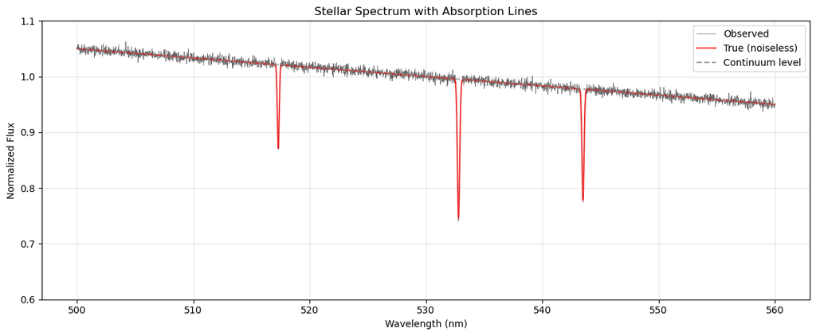

```python
# Create wavelength array (in nanometers)
wavelength = np.linspace(500, 560, 3000)  # 60 nm range, 0.02 nm sampling

# Create continuum with a small slope
continuum = 1.0 - 0.05 * (wavelength - 530) / 30  # small positive slope

# Add absorption lines at specific wavelengths (representing different elements)
# Line 1: Magnesium at 517.3 nm
line1_center = 517.3
line1_depth = 0.15
line1_width = 0.08
absorption1 = line1_depth * np.exp(-0.5 * ((wavelength - line1_center) / line1_width)**2)

# Line 2: Iron at 532.8 nm
line2_center = 532.8
line2_depth = 0.25
line2_width = 0.10
absorption2 = line2_depth * np.exp(-0.5 * ((wavelength - line2_center) / line2_width)**2)

# Line 3: Iron at 543.5 nm
line3_center = 543.5
line3_depth = 0.20
line3_width = 0.09
absorption3 = line3_depth * np.exp(-0.5 * ((wavelength - line3_center) / line3_width)**2)

# Combine: continuum minus absorption
flux = continuum - absorption1 - absorption2 - absorption3

# Add realistic noise
noise_level = 0.005
flux_noisy = flux + np.random.normal(0, noise_level, len(wavelength))

# Plot the spectrum
plt.figure(figsize=(12, 5))
plt.plot(wavelength, flux_noisy, 'k-', linewidth=0.5, alpha=0.6, label='Observed')
plt.plot(wavelength, flux, 'r-', linewidth=1.5, alpha=0.7, label='True (noiseless)')
plt.plot(wavelength, continuum, color='gray', linestyle='--', alpha=0.7, label='Continuum level')  # plot the sloped continuum
plt.xlabel('Wavelength (nm)')
plt.ylabel('Normalized Flux')
plt.title('Stellar Spectrum with Absorption Lines')
plt.ylim([0.6, 1.1])
plt.legend()
plt.grid(alpha=0.3)
plt.tight_layout()
plt.show()
```

This synthetic spectrum illustrates the key features of stellar spectra. The continuum (dashed gray line) shows only a gentle slope here because we're viewing just a small piece of the full continuum across the star's spectrum. In reality, this slope is part of the underlying blackbody emission from the stellar photosphere. Three absorption lines appear as dips below the continuum at specific wavelengths—517.3 nm (magnesium), 532.8 nm (iron), and 543.5 nm (iron).

The line at 532.8 nm is deepest (25% absorption), which could indicate either a strong atomic transition (high oscillator strength) or high abundance of that element. Notice that the lines have finite width—they're not infinitely sharp—for physical reasons involving thermal motion, pressure, and quantum mechanics that we'll explore later. The noisy observed spectrum (black) fluctuates around the true noiseless spectrum (red) due to photon counting statistics (Poisson noise) and detector readout noise.

In practice, stellar spectra contain hundreds to thousands of lines, especially for cool stars where many atomic and molecular transitions occur at visible wavelengths. Our simple three-line example lets us focus on analysis techniques without overwhelming complexity.

### The Photometry-Spectroscopy Trade-off

This wavelength-resolved information comes at a cost. In photometry, a broadband filter (e.g., V-band with $\sim 90\,\mathrm{nm}$ width) concentrates all incoming photons onto a single detector element, resulting in high signal-to-noise ratios (S/N). In contrast, spectroscopy spreads the same total photon flux across hundreds or thousands of narrow wavelength bins, so each bin receives far fewer photons—typically $\sim N$ times fewer for $N$ bins. For example, in a medium-resolution spectrograph with $1000$ spectral bins, each bin collects about $1000$ times fewer photons than a broad-band photometric measurement.

Because S/N in the photon-limited regime improves as the square root of the number of photons (the $\sqrt{N}$ improvement we discussed in Lecture 17), photometry’s S/N is correspondingly higher: you “combine” all the signal in one measurement, while spectroscopy divides it up. To reach similar S/N per bin in spectroscopy, you require much longer exposure times—often hundreds or thousands of times as long as for photometry. This explains why photometry excels in time-domain surveys (e.g., exoplanet transits, variable stars, supernova searches), where high S/N and rapid cadence are crucial, while spectroscopy is typically reserved for specialized, in-depth physical characterization (like measuring chemical abundances, velocities, and temperatures) where the extra information per photon justifies the loss in raw S/N.

## Spectral Resolution: Measuring the Sharpness of Your Rainbow

Just as angular resolution determined how well we could separate nearby stars in images (Lecture 20), spectral resolution determines how well we can separate nearby wavelength features in spectra. Spectral resolution quantifies how finely your spectrograph can distinguish different wavelengths.

Spectral resolution R is defined as:

$$R = \frac{\lambda}{\Delta\lambda}$$

where $\lambda$ is the wavelength of interest and $\Delta\lambda$ is the smallest wavelength difference you can resolve. A spectrograph with R = 1000 operating at $\lambda$ = 500 nm can resolve features separated by $\Delta\lambda$ = 500 nm / 1000 = 0.5 nm. Two spectral lines closer than 0.5 nm apart will blur together; lines farther apart will be distinguishable.

Importantly, $\Delta\lambda$ is typically defined as the Full Width at Half Maximum (FWHM) of the instrument's response to a monochromatic source. If you observe a sharp laser line, the spectrograph spreads it into a profile with some width—that width is $\Delta\lambda$. This is exactly analogous to the PSF FWHM we learned about in Lecture 20! Just as the PSF described how a point source spreads spatially in an image, the instrumental line profile describes how a monochromatic source spreads spectrally.

The connection to FWHM means we can write:

$$R = \frac{\lambda}{\text{FWHM}_\lambda}$$

This relationship between resolution and FWHM is crucial for understanding what we can measure from spectra. A high-resolution spectrograph ($R \sim 50,000$ to $100,000$) has small FWHM, allowing measurement of narrow line details. A low-resolution spectrograph ($R \sim 100$ to $1,000$) has large FWHM, blurring lines together.

Let's calculate the FWHM for different instrument types:

```python
# Calculate spectral resolution parameters for different instruments

# Define spectrograph configurations
configs = {
    'Low-res (imaging spectrograph)': 100,
    'Medium-res (multi-object)': 2000,
    'High-res (echelle)': 50000,
    'Ultra-high-res (laser comb)': 100000
}

# Reference wavelength
lambda_ref = 500 * u.nm

print("Spectral Resolution Comparison at λ = 500 nm:\n")
print(f"{'Configuration':<30} {'R':<10} {'FWHM (nm)':<12}")
print("-" * 55)

for name, R in configs.items():
    # Calculate FWHM in wavelength using astropy
    delta_lambda = lambda_ref / R
    print(f"{name:<30} {R:<10} {delta_lambda.value:<12.3f}")
```

```
Spectral Resolution Comparison at λ = 500 nm:

Configuration                  R          FWHM (nm)
-------------------------------------------------------
Low-res (imaging spectrograph) 100        5.000
Medium-res (multi-object)      2000       0.250
High-res (echelle)             50000      0.010
Ultra-high-res (laser comb)    100000     0.005
```

Many famous astronomical surveys and telescopes are designed around their spectral resolution to fit specific science goals. For example, the Sloan Digital Sky Survey (SDSS) in its early phases used a spectrograph with a resolution of about $R \sim 2000$, though more recent SDSS projects (like APOGEE) use much higher resolution, around $R \sim 20,000$. The LAMOST survey, another massive stellar survey, also uses a multi-object spectrograph at $R \sim 2000$. These values of $R$ mean that such instruments can separate light into enough detail to pick out broad spectral features from hundreds or thousands of stars or galaxies at once, making them excellent for mapping large-scale structures in the universe.

Large surveys like SDSS, LAMOST, and APOGEE take advantage of what are called "multi-object spectrographs"—clever devices that let astronomers record the spectra of many different stars or galaxies simultaneously, like taking hundreds of rainbow fingerprints in a single exposure.

On the other hand, when astronomers want to study very fine details in a star’s light—such as the tiny wobbling motion caused by an orbiting planet—they turn to high-resolution instruments. HIRES at the Keck Observatory is a good example, with $R$ around 50,000, and HARPS in Chile can go even higher, reaching $R \sim 110,000$. The higher the spectral resolution $R$, the tinier the differences in color (or wavelength) that can be distinguished, almost like having a microscope for rainbows. You’ll often see the term FWHM, which stands for "Full Width at Half Maximum." This technical phrase just measures how much a sharp, single color of light gets spread out—the narrower the FWHM, the sharper the details you can see in the spectrum.

By building instruments with different values of $R$ and FWHM, astronomers can choose between observing lots of objects with coarser detail or zooming in on a few objects to see the smallest features in their spectra. In each case, the instrument's design—its resolution, and whether it can observe many objects at once—matches the scientific questions the astronomers are trying to answer, whether that's mapping the whole sky or searching for new exoplanets.

#### How Instrumental Resolution Affects Spectral Lines

To understand how resolution affects observations, we need to briefly introduce the concept of line profiles. Spectral lines are not infinitely narrow—they have shapes described by mathematical functions. The most common shape is the Gaussian profile:

$$f(\lambda) = 1 - A \exp\left(-\frac{(\lambda - \lambda_0)^2}{2\sigma^2}\right)$$

where $\lambda_0$ is the line center, $A$ is the line depth (how much flux is absorbed), and $\sigma$ determines the line width. The Full Width at Half Maximum (FWHM) relates to $\sigma$ as FWHM $= 2.355\sigma$. This bell-shaped curve describes many physical broadening mechanisms we'll explore later (thermal motion, for example).

When light passes through a spectrograph, the **instrumental profile** also has a Gaussian shape with width determined by the instrument's resolution. The observed line is created by **convolution**—a mathematical operation that "smears" the intrinsic line by the instrumental profile. Crucially, convolution preserves the **equivalent width** (the total absorbed flux, i.e., the integral of the absorption). This means when a line is broadened by lower resolution, it becomes wider but shallower, keeping the total absorbed light constant.

Let's visualize how different resolutions affect what we actually see:

```python
# Simulate how instrumental resolution affects a spectral line

# Create wavelength array
wavelength_fine = np.linspace(528, 537, 9000)
line_center = 532.5

# Create a narrow absorption line (Gaussian profile)
line_width_intrinsic = 0.01  # nm - represents natural line width (sigma)
flux_intrinsic = 1.0 - 0.5 * np.exp(-0.5 * ((wavelength_fine - line_center) / line_width_intrinsic)**2)

# Different instrument resolutions with their FWHMs
resolutions = {
    'R = 100,000 (ultra-high)': 0.005,  # FWHM in nm
    'R = 50,000 (high)': 0.010,
    'R = 10,000 (medium)': 0.050,
    'R = 2,000 (low)': 0.250
}
```

Now we'll observe this narrow intrinsic line through four different spectrographs. When light passes through an instrument, the instrumental profile (determined by the spectrograph's resolution) convolves with the intrinsic line profile.

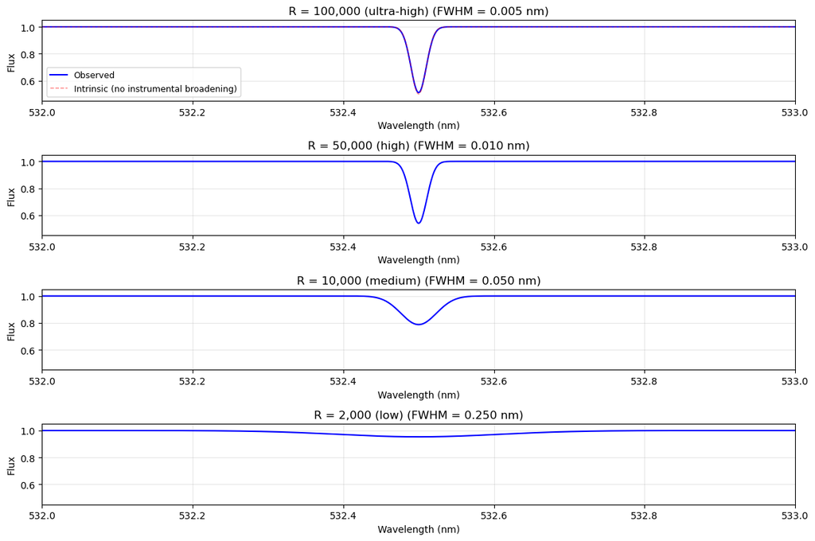

```python
# Plot
plt.figure(figsize=(12, 8))

for i, (label, fwhm_nm) in enumerate(resolutions.items()):
    # Convert FWHM to sigma for the instrumental profile
    sigma_instrument = fwhm_nm / 2.355

    # Convolve intrinsic profile with instrumental profile
    # When we convolve two Gaussians with sigmas σ₁ and σ₂, we get a Gaussian with σ = √(σ₁² + σ₂²)
    sigma_observed = np.sqrt(line_width_intrinsic**2 + sigma_instrument**2)

    # To preserve equivalent width (EW ∝ amplitude × sigma), adjust amplitude
    # As line gets broader (larger sigma), it must get shallower (smaller amplitude)
    amplitude_intrinsic = 0.5
    amplitude_observed = amplitude_intrinsic * (line_width_intrinsic / sigma_observed)

    # Create the broadened line (wider but shallower, preserving total absorbed flux)
    flux_observed = 1.0 - amplitude_observed * np.exp(-0.5 * ((wavelength_fine - line_center) / sigma_observed)**2)

    # Plot
    plt.subplot(4, 1, i+1)
    mask = (wavelength_fine >= 530) & (wavelength_fine <= 535)
    plt.plot(wavelength_fine[mask], flux_observed[mask], 'b-', linewidth=1.5, label='Observed')
    if i == 0:
        plt.plot(wavelength_fine[mask], flux_intrinsic[mask], 'r--', linewidth=1, alpha=0.5,
                label='Intrinsic (no instrumental broadening)')
    plt.xlabel('Wavelength (nm)')
    plt.ylabel('Flux')
    plt.title(label + f' (FWHM = {fwhm_nm:.3f} nm)')
    plt.ylim([0.45, 1.05])
    plt.xlim([532, 533])
    plt.grid(alpha=0.3)
    if i == 0:
        plt.legend(fontsize=9)

plt.tight_layout()
plt.show()
```

The visualization dramatically shows resolution's impact. At $R = 100,000$ (top panel), the observed line (blue) closely matches the intrinsic narrow line profile (dashed red line)—the instrumental broadening is small. At $R = 50,000$, we start seeing noticeable broadening. At $R = 10,000$ (medium resolution), the line is significantly smeared out—notice how it becomes both **wider and shallower**, preserving the total absorbed flux (equivalent width). At $R = 2,000$ (low resolution), the line is severely broadened—if multiple lines were close together, they would blur into one feature.

A crucial physical point: the total amount of absorbed light (the area under the absorption feature) remains constant across all resolutions. Lower resolution doesn't make absorption disappear—it just spreads it out, making lines wider and shallower. This flux conservation is fundamental to understanding how instruments affect our measurements.

This explains why choosing the right spectrograph resolution is crucial. Too low, and you cannot resolve the features you need. Too high, and you waste photons (remember: higher resolution spreads light thinner across the detector) without gaining useful information. The "right" resolution depends on your science goal and the natural width of the features you're studying.

### Resolution and Radial Velocity Precision

Spectral resolution has profound implications for measuring stellar velocities. Recall from the introduction that spectral line positions reveal velocities through the Doppler effect. Here's how it works: when a star moves toward us at velocity $v$, all its spectral lines shift to shorter wavelengths (blueshift). When it moves away, lines shift to longer wavelengths (redshift). The Doppler formula relates velocity to wavelength shift:

$$\frac{\Delta\lambda}{\lambda} = \frac{v}{c}$$

where $\Delta\lambda$ is the wavelength shift, $\lambda$ is the rest wavelength, $v$ is the radial velocity, and $c$ is the speed of light. A star moving at $v = 30$ km/s toward us will have all its lines shifted by $\Delta\lambda/\lambda = 30/299,792 \approx 10^{-4}$, or about 0.05 nm at $\lambda = 500$ nm.

To measure this velocity, we must detect the wavelength shift. Spectral resolution directly constrains radial velocity precision—to detect a shift, it must be larger than (or at least comparable to) the instrumental FWHM. We can express the instrumental resolution in velocity units using the same Doppler formula. The FWHM in velocity is:

$$\text{FWHM}_v = c \times \frac{\Delta\lambda}{\lambda} = \frac{c}{R}$$

Let's recalculate our resolution table in both wavelength and velocity units:

```python
# Calculate spectral resolution in wavelength and velocity units
print("Spectral Resolution in Wavelength and Velocity Units (λ = 500 nm):\n")
print(f"{'Configuration':<30} {'R':<10} {'FWHM (nm)':<12} {'FWHM (km/s)':<15}")
print("-" * 70)

for name, R in configs.items():
    # Calculate FWHM in wavelength
    delta_lambda = lambda_ref / R

    # Convert to velocity using Doppler formula: FWHM_v = c / R
    v_fwhm = (const.c / R).to(u.km / u.s)

    print(f"{name:<30} {R:<10} {delta_lambda.value:<12.3f} {v_fwhm.value:<15.2f}")
```

```
Spectral Resolution in Wavelength and Velocity Units (λ = 500 nm):

Configuration                  R          FWHM (nm)    FWHM (km/s)
----------------------------------------------------------------------
Low-res (imaging spectrograph) 100        5.000        2997.92
Medium-res (multi-object)      2000       0.250        149.90
High-res (echelle)             50000      0.010        6.00
Ultra-high-res (laser comb)    100000     0.005        3.00
```

The velocity FWHM shows the minimum velocity shift readily detectable by each instrument. A low-resolution spectrograph with FWHM = 3000 km/s can measure velocities of massive objects like galaxies but struggles with stellar radial velocities (typically 10-100 km/s). High-resolution instruments with FWHM = 3-6 km/s can measure stellar velocities and even detect exoplanets.

In practice, you can measure line centers to better precision than the FWHM if you have high signal-to-noise ratio—typically 1/10 to 1/20 of the instrumental FWHM. This means achievable RV precision scales as:

$$\sigma_v \approx \frac{c}{10R} \text{ to } \frac{c}{20R}$$

Let's calculate achievable precision for our instrument suite:

```python
# Calculate radial velocity precision limits
print("Achievable Radial Velocity Precision (with high S/N):\n")
print(f"{'Configuration':<30} {'R':<10} {'Best RV Precision':<20}")
print("-" * 65)

for name, R in configs.items():
    # Achievable RV precision: roughly c/(10R) for high S/N
    rv_precision = (const.c / (10 * R)).to(u.km / u.s)

    print(f"{name:<30} {R:<10} {rv_precision.value:<20.2f} km/s")
```

```
Achievable Radial Velocity Precision (with high S/N):

Configuration                  R          Best RV Precision
-----------------------------------------------------------------
Low-res (imaging spectrograph) 100        299.79               km/s
Medium-res (multi-object)      2000       14.99                km/s
High-res (echelle)             50000      0.60                 km/s
Ultra-high-res (laser comb)    100000     0.30                 km/s
```

### Connection to Exoplanet Detection

The single-line precision values in the table represent fundamental limits, but modern instruments do much better by exploiting a powerful trick. The table shows that at $R = 100,000$, single-line precision is ~300 m/s—far too coarse to detect Jupiter's 12.5 m/s signal, let alone Earth's 9 cm/s wobble. However, stellar spectra contain thousands of absorption lines. By measuring the Doppler shift of many lines simultaneously and combining them statistically, the effective precision improves as $1/\sqrt{N_{\text{lines}}}$. With $N \sim 10,000$ lines, precision improves by a factor of ~100, bringing 300 m/s down to ~3 m/s.

State-of-the-art instruments like ESPRESSO push this further with extreme wavelength calibration stability, achieving ~10 cm/s precision—approaching the threshold needed to detect Earth analogs. This is why high-resolution spectroscopy ($R \sim 100,000$) is essential for exoplanet detection: it provides both the fine resolution needed to measure many lines and the narrow line widths that enable precise centroid measurements.

## Natural Broadening Mechanisms

We've seen how instrumental resolution affects our ability to separate nearby spectral features and measure radial velocities. But there's a deeper question: even with perfect instrumentation, how narrow can spectral lines actually be? The answer reveals fundamental physics: spectral lines have natural width due to physical processes in stellar atmospheres. Even with infinite resolution, lines would not be infinitely sharp.

Understanding these natural broadening mechanisms is essential because, ultimately, we will fit mathematical models to observed spectral lines to extract physical parameters—stellar temperatures from line widths, rotation rates from broadening, radial velocities from line centers, and elemental abundances from line depths. To build accurate models for fitting, we need to understand both the underlying physics (why lines broaden) and their mathematical forms (the specific functions that describe each broadening mechanism). This section develops that understanding, explaining which physical processes produce which profile shapes, so that when we implement curve fitting later, we'll know which functional forms to use and what their parameters mean physically.

### Natural Broadening

Quantum mechanics fundamentally limits the sharpness of spectral lines through the Heisenberg uncertainty principle, which states that the product of the uncertainty in energy ($\Delta E$) and the uncertainty in time ($\Delta t$), where $\Delta t$ is the mean lifetime of the excited atomic state (typically about $10^{-8}$ seconds), must satisfy $\Delta E \times \Delta t \geq \hbar/2$, with $\hbar$ representing the reduced Planck constant ($\hbar = h/2\pi$) and $h$ being Planck’s constant. Because each excited state only exists for a finite time, there is an inherent uncertainty in its energy ($\Delta E$), which directly leads to an uncertainty in the photon frequency ($\nu$, related by $E = h\nu$) and thus the wavelength of light emitted or absorbed. This results in "natural broadening": even for a single, motionless atom in a vacuum, spectral lines exhibit a small but finite width due solely to the quantum mechanical uncertainty in the energy of the transition. (Variables: $\Delta E$ = energy uncertainty, $\Delta t$ = excited state lifetime, $h$ = Planck constant, $\hbar$ = reduced Planck constant, $\nu$ = photon frequency.)

Natural broadening produces a Lorentzian profile (defined below). For typical optical transitions, the natural width is extraordinarily small—around 0.0001 nm at 500 nm, corresponding to $R \sim 5,000,000$. This is much narrower than achievable spectral resolution, so natural broadening is rarely the dominant effect for optical spectra.

### Thermal Broadening (Doppler Broadening)

Gas atoms in stellar atmospheres are not at rest—they're in constant thermal motion with velocities distributed according to the Maxwell-Boltzmann distribution. At typical stellar temperatures ($T \sim 5000$-$10,000$ K), random thermal velocities are several kilometers per second. When an atom moving toward us absorbs or emits light, the wavelength is Doppler-shifted to shorter wavelengths (blueshifted). An atom moving away produces a redshift. Since atoms have a distribution of velocities, the line profile reflects this velocity distribution.

For a gas at temperature $T$, the velocity distribution is Gaussian with characteristic velocity:

$$v_{th} = \sqrt{\frac{2k_BT}{m}}$$

where $k_B$ is Boltzmann's constant and $m$ is the atomic mass. Lighter atoms move faster at the same temperature, producing broader lines. This thermal broadening produces a Gaussian profile with FWHM:

$$\Delta\lambda_{th} = \frac{\lambda}{c} \sqrt{\frac{8 k_B T \ln 2}{m}}$$

For hydrogen at $T = 6000 {\rm K}$ around $\lambda = 500 {\rm nm}$, this gives $\Delta\lambda \sim 0.02 {\rm nm}$, corresponding to $R \sim 25,000$. Thermal broadening is typically the dominant intrinsic broadening mechanism in stellar spectra.

### Pressure Broadening

In dense stellar atmospheres, atoms collide with each other frequently. These collisions perturb energy levels, interrupting emission/absorption processes and broadening lines. Pressure broadening increases with atmospheric density—deeper layers where pressure is higher show broader lines. This broadening also produces a Lorentzian profile.

Pressure broadening becomes important in cool, dense atmospheres (like low-mass stars) and for strong resonance transitions. For typical solar-type stars, pressure broadening contributes a few percent to the total line width.

### Rotational Broadening

Stellar rotation is an important physical parameter, but measuring it presents a challenge. Recall from Lecture 20 that even with the best telescopes, stars appear as unresolved point sources—we cannot directly image the stellar disk or see surface features rotating across it. Unlike planets (where we can track surface features) or galaxies (where we can measure rotation curves from spatially-resolved spectra), stars are too distant and too small to resolve spatially.

However, spectroscopy provides an elegant solution. If a star rotates, different parts of the visible disk move with different velocities relative to us. One limb (edge) rotates toward us (blueshifted) while the opposite limb rotates away (redshifted). Even though we cannot spatially resolve the star, light from all parts of the disk adds together in our spectrograph, creating a broadened spectral line whose width encodes the rotation velocity.

However, we cannot measure the true equatorial rotation velocity $v$ directly—we can only measure the projected velocity $v \sin i$, where $i$ is the inclination angle. This is exactly analogous to the transit and radial velocity geometries from Lecture 19! Just as we could only measure $M_p \sin i$ from radial velocities (because we don't know if we're viewing the orbit edge-on or face-on), we can only measure $v \sin i$ from spectral line widths because we don't know if we're viewing the star's equator ($i = 90°$, edge-on, maximum broadening) or pole ($i = 0°$, face-on, no broadening).

The geometry works like this: if a star rotates with equatorial velocity $v$ and we view it at inclination $i$, the maximum velocity difference across the visible disk is $2v \sin i$. Light from the approaching limb is blueshifted by $v \sin i$, light from the receding limb is redshifted by $v \sin i$, and light from the center has minimal Doppler shift. All this light combines to produce the observed line profile.

For a star rotating with projected velocity $v \sin (i)$, the rotational broadening adds to the line width. The full wavelength span from the bluest (approaching limb) to the reddest (receding limb) wavelength is:

$$\Delta\lambda_{rot} = \frac{2\lambda}{c} v \sin i$$

This represents the full Doppler extent of the rotation. The actual FWHM of the rotational profile is somewhat smaller (typically 60-70% of this full width, depending on limb darkening), but the order of magnitude is correct. For a rapidly rotating star ($v \sin i = 100 {\rm km/s}$) at $\lambda = 500 {\rm nm}$, this gives $\Delta\lambda \sim 0.33 {\rm nm}$—much larger than thermal broadening! Rotation often dominates the line width for hot, rapidly-rotating stars.

Let's visualize the geometry of rotational broadening:

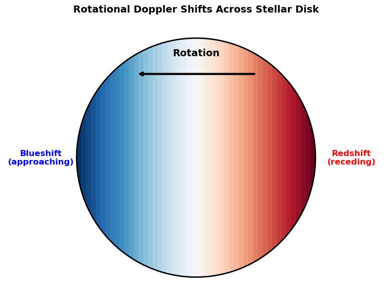

```python
# Visualize rotating star with Doppler shift gradient
fig, ax = plt.subplots(1, 1, figsize=(8, 8))

# Create a grid for the star
x = np.linspace(-1, 1, 500)
y = np.linspace(-1, 1, 500)
X, Y = np.meshgrid(x, y)

# Mask for circular star
R = np.sqrt(X**2 + Y**2)
star_mask = R <= 1.0

# Doppler shift depends on x-position (left = approaching = blue, right = receding = red)
# Create color map from blue to white to red
doppler_shift = np.copy(X)
doppler_shift[~star_mask] = np.nan

# Plot star with blue-to-red gradient
im = ax.contourf(X, Y, doppler_shift, levels=50, cmap='RdBu_r', vmin=-1, vmax=1)
ax.contour(X, Y, R, levels=[1.0], colors='black', linewidths=2)

# Add rotation arrow
arrow_y = 0.7
ax.annotate('', xy=(-0.5, arrow_y), xytext=(0.5, arrow_y),
            arrowprops=dict(arrowstyle='->', lw=3, color='black'))
ax.text(0, arrow_y + 0.15, 'Rotation', fontsize=14, ha='center', weight='bold')

# Add labels
ax.text(-1.3, 0, 'Blueshift\n(approaching)', fontsize=12, ha='center',
        va='center', color='blue', weight='bold')
ax.text(1.3, 0, 'Redshift\n(receding)', fontsize=12, ha='center',
        va='center', color='red', weight='bold')

ax.set_xlim(-1.6, 1.6)
ax.set_ylim(-1.2, 1.1)
ax.set_aspect('equal')
ax.axis('off')
ax.set_title('Rotational Doppler Shifts Across Stellar Disk', fontsize=14, weight='bold', pad=20)

plt.tight_layout()
plt.show()
```

The diagram illustrates why rotation broadens spectral lines. Different parts of the stellar disk move with different velocities relative to us. The approaching limb on the left (moving toward us) produces blueshifted light, while the receding limb on the right (moving away) produces redshifted light. The center of the disk has minimal Doppler shift since it moves perpendicular to our line of sight.

All this light adds together, spreading the spectral line across a range of wavelengths. The faster the rotation, the larger the wavelength spread and the broader the line becomes.

### Resolution Limits on Measuring Rotation

Just as with radial velocities, our ability to detect rotational broadening is fundamentally limited by spectral resolution. The observed width of a spectral line combines both the star's intrinsic broadening (such as rotation) and the broadening introduced by the instrument (the "instrumental width").

This can be understood by considering the relationship $\Delta \lambda / \lambda = v/c$, where a velocity $v$ causes a shift $\Delta \lambda$ of a line at wavelength $\lambda$. The spectrograph's resolving power is $R = \lambda/\Delta\lambda_{\rm inst}$, meaning the smallest wavelength difference it can distinguish is $\Delta\lambda_{\rm inst} = \lambda/R$.

The *instrumental velocity resolution* that corresponds to this is $v_{\rm inst} = c/R$. In order to detect rotational broadening, the velocity span caused by rotation ($v\sin(i)$ – the maximum projected rotational velocity at the stellar equator) must be at least comparable to $v_{\rm inst}$. In other words, you generally can't measure rotational broadening less than what the spectrograph blurs out.

Therefore, the minimum measurable rotational velocity is set by $v\sin(i)_{\rm min} \sim c/R$.

```python
# Calculate minimum detectable rotation velocities
print("Minimum Detectable Rotation Velocity:\n")
print(f"{'Configuration':<30} {'R':<10} {'v sin(i) limit':<20}")
print("-" * 65)

lambda_ref_rot = 500 * u.nm

for name, R in configs.items():
    # Instrumental FWHM in velocity
    v_inst = (const.c / R).to(u.km / u.s)

    # Need rotational width to be ~2x instrumental width to detect reliably
    # Rotational FWHM ≈ 2 × v sin(i) × λ/c
    # So minimum v sin(i) ≈ instrumental FWHM ≈ c/R
    v_sini_min = v_inst

    print(f"{name:<30} {R:<10} ~{v_sini_min.value:<19.1f} km/s")
```

```
Minimum Detectable Rotation Velocity:

Configuration                  R          v sin(i) limit
-----------------------------------------------------------------
Low-res (imaging spectrograph) 100        ~2997.9              km/s
Medium-res (multi-object)      2000       ~149.9               km/s
High-res (echelle)             50000      ~6.0                 km/s
Ultra-high-res (laser comb)    100000     ~3.0                 km/s
```

Detecting slow rotators, such as stars similar to the Sun, requires instruments with extremely high spectral resolution. For example, the Sun* has an equatorial velocity of about $v_{\text{eq}} \sim 2$ km/s, meaning its projected rotational velocity $v \sin i$ is typically in the range of $1$–$2$ km/s. Such small values of $v \sin i$ are only barely detectable even with spectrographs that reach resolutions of $R \sim 100,\!000$ or higher.

In contrast, stars like Vega (A0 type) rotate more rapidly, with $v \sin i$ around $20$ km/s; this level of broadening is easily detected at moderate resolution ($R \sim 10,\!000$). For very rapidly rotating stars, where $v \sin i$ approaches $200$ km/s, the rotation dominates the spectral line width, and even instruments with relatively low resolution ($R \sim 1,\!000$) can clearly measure the effect.

These comparisons highlight why high-resolution spectroscopy is essential for studying slowly rotating stars like the Sun, while hotter or younger stars that rotate more quickly can be analyzed with lower-resolution instruments. The minimum $v \sin i$ that can be measured is fundamentally bounded by the resolving power of the instrument. Furthermore, as stars age, they lose angular momentum through magnetic braking, causing their rotation to slow and making old, slowly rotating stars among the most challenging cases for rotational velocity studies.

## Spectral Line Profile Shapes

Now that we understand why lines have finite width from different physical mechanisms, let's define the mathematical functions used to model line profiles. Just as we used Gaussian PSFs to model stellar images in Lecture 20, we'll use specific functions to model spectral line shapes. The choice of function depends on which physical broadening mechanism dominates.

### Gaussian Profile

The Gaussian profile models both thermal (Doppler) broadening and instrumental broadening. This occurs because, in both scenarios, the observed line profile results from the sum of many tiny, independent effects—either the random velocities of particles in the gas (for thermal Doppler broadening) or the numerous independent sources of error and imperfections in the instrument optics (for instrumental broadening).

In both cases, the Central Limit Theorem applies: whenever you add up a large number of independent random effects, regardless of their individual distributions (as long as they have finite variance), the resulting overall distribution will tend toward a Gaussian (normal) distribution. This is why both thermal motion (the sum of many random atomic velocities) and instrumental effects (the combination of many small, independent influences in the spectrograph) naturally produce line profiles that are well described by the Gaussian function.

For an absorption line, the observed flux as a function of wavelength has the form of an "upside down" Gaussian—meaning it is a Gaussian subtracted from the continuum level (rather than a Gaussian bump above the continuum). Mathematically, this looks like:

$$F(\lambda) = F_c - A \exp\left[-\frac{(\lambda - \lambda_0)^2}{2\sigma^2}\right]$$

where $F_c$ is the continuum level (flux far from the line), $A$ is the line amplitude (depth below continuum), $\lambda_0$ is the line center wavelength, and $\sigma$ is the Gaussian width parameter. The full width at half maximum (FWHM) relates to $\sigma$ by: FWHM = 2.355 $\times$ $\sigma$. This is the same Gaussian function we used for PSF fitting in Lecture 20—the mathematics is identical, just applied to wavelength instead of spatial position!

### Lorentzian Profile

The Lorentzian profile (also called Cauchy profile) models natural broadening and pressure broadening. For an absorption line:

$$F(\lambda) = F_c - \frac{A}{1 + \left[\frac{2(\lambda - \lambda_0)}{\gamma}\right]^2}$$

where $\gamma$ is the Lorentzian FWHM parameter (full width at half maximum) and the other parameters have the same meaning as in the Gaussian profile. The Lorentzian has much broader wings than a Gaussian—it decays as 1/$\Delta\lambda$² far from the line center rather than exponentially. These extended wings are physically important: they carry information about collisional processes and can affect neighboring lines.

### Voigt Profile: The Default Choice

The Voigt profile is the most physically accurate description of spectral lines because it combines both thermal/instrumental broadening (Gaussian) and natural/pressure broadening (Lorentzian). It is formed by the convolution of these two profile types.

What is convolution? Imagine you have two blurring effects happening sequentially: first thermal motion blurs the line (creating a Gaussian), then collisional processes blur it further (adding a Lorentzian). Mathematically, convolution describes how these effects combine. Think of it like this: you take the Gaussian profile, and at each wavelength point, you "smear it out" according to the Lorentzian shape. The result is the Voigt profile, which has characteristics of both parent functions.

The mathematical form is:

$$V(\lambda) = \int_{-\infty}^{\infty} G(\lambda') L(\lambda - \lambda') d\lambda'$$

where G is a Gaussian and L is a Lorentzian. While this convolution cannot be expressed in closed form using elementary functions, it can be efficiently computed using `scipy.special.voigt_profile`.

The Voigt profile has a Gaussian core (dominated by thermal motion) with Lorentzian wings (dominated by collisions). This is the realistic behavior of stellar spectral lines: thermal motion dominates near the line center, while collisional broadening matters primarily in the wings.

Limiting cases: The Voigt profile is a generalization that reduces to simpler forms in special cases. When the Lorentzian width $\gamma$ approaches zero (negligible pressure broadening), the Voigt profile becomes purely Gaussian. When the Gaussian width $\sigma$ approaches zero (negligible thermal broadening), the Voigt profile becomes purely Lorentzian. In practice, both effects contribute, so Voigt is the appropriate choice.

Having defined the mathematical forms, let's visualize how these three profile types compare:

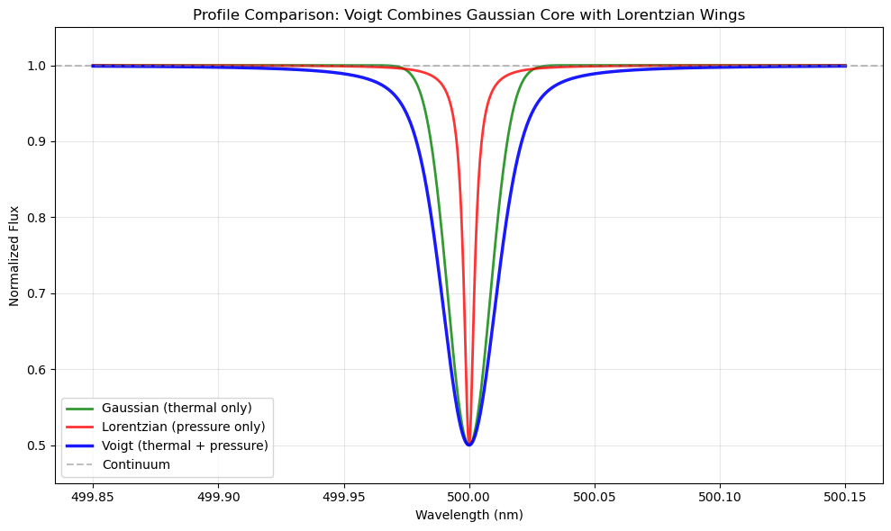

```python
# Visualize Gaussian, Lorentzian, and Voigt profiles
wavelength = np.linspace(499.85, 500.15, 1000)
continuum = 1.0
amplitude = 0.5
center = 500.0

# Typical stellar line parameters
sigma = 0.020 / 2.355  # Thermal broadening (FWHM = 0.020 nm)
gamma = 0.005  # Pressure broadening (FWHM = 0.005 nm)

# Create profiles directly (without defining functions yet)
# Gaussian
flux_gaussian = continuum - amplitude * np.exp(-0.5 * ((wavelength - center) / sigma)**2)

# Lorentzian
flux_lorentzian = continuum - amplitude / (1 + (2 * (wavelength - center) / gamma)**2)

# Voigt (using scipy voigt_profile function)
from scipy.special import voigt_profile as scipy_voigt
x = wavelength - center
voigt = scipy_voigt(x, sigma, gamma)
voigt = voigt / voigt.max()  # Normalize
flux_voigt = continuum - amplitude * voigt

# Plot comparison
plt.figure(figsize=(10, 6))
plt.plot(wavelength, flux_gaussian, 'g-', linewidth=2, label='Gaussian (thermal only)', alpha=0.8)
plt.plot(wavelength, flux_lorentzian, 'r-', linewidth=2, label='Lorentzian (pressure only)', alpha=0.8)
plt.plot(wavelength, flux_voigt, 'b-', linewidth=2.5, label='Voigt (thermal + pressure)', alpha=0.9)
plt.axhline(y=continuum, color='gray', linestyle='--', alpha=0.5, label='Continuum')
plt.xlabel('Wavelength (nm)')
plt.ylabel('Normalized Flux')
plt.title('Profile Comparison: Voigt Combines Gaussian Core with Lorentzian Wings')
plt.legend()
plt.ylim([0.45, 1.05])
plt.grid(alpha=0.3)
plt.tight_layout()
plt.show()
```

The visualization shows how the Voigt profile (blue) combines features of both the Gaussian (green) and Lorentzian (red). The Voigt profile has a Gaussian-like core (dominated by thermal motion) but Lorentzian-like extended wings (dominated by collisions)—capturing the physics of both broadening mechanisms in a single model. This is why Voigt is the physically correct choice for stellar spectral lines.

For the remainder of this lecture, we will use Voigt profiles as our standard model when fitting spectral lines.

## Fitting Spectral Lines with Voigt Profiles

Now let's apply our curve-fitting skills to extract parameters from spectral lines using Voigt profiles. We'll use `scipy.optimize.curve_fit`—the same tool we used for transit fitting (Lecture 19) and PSF fitting (Lecture 20). The principles are identical: define a model function, provide initial guesses, and let the optimizer find the best-fit parameters.

The crucial element in constructing a Voigt profile numerically is the use of the `voigt_profile` function from `scipy.special`. The Voigt profile is, by definition, a convolution of a Gaussian (thermal broadening) and Lorentzian (pressure broadening), and this convolution has no simple analytic form. However, it can be computed efficiently and accurately using scipy's built-in `voigt_profile` function.

In the code below, you'll see that the calculation of the Voigt profile centers around calling `voigt_profile(x, sigma, gamma)` at each wavelength, where `x` is the distance from the line center, and `sigma` and `gamma` encode the relative contributions of Gaussian and Lorentzian widths. Normalizing this profile and scaling it by an amplitude yields the final model flux. This mathematical connection means that our model function directly returns the physical profile expected from both broadening mechanisms—making the fit physically meaningful.

- the continuum level (baseline flux across the line),
- the line amplitude (depth of the absorption below the continuum),
- the line center (wavelength position of the line),
- the Gaussian sigma (thermal broadening width),
- and the Lorentzian gamma (pressure broadening width).

All of these parameters shape the appearance and position of the absorption feature in the spectrum.

```python
from scipy.special import voigt_profile as scipy_voigt

def voigt_line(wavelength, continuum, amplitude, center, sigma, gamma):
    """
    Voigt absorption line profile (Gaussian convolved with Lorentzian).

    Parameters:
    -----------
    wavelength : array
        Wavelength array
    continuum : float
        Continuum flux level
    amplitude : float
        Line depth (absorption below continuum)
    center : float
        Line center wavelength
    sigma : float
        Gaussian width parameter (thermal broadening)
    gamma : float
        Lorentzian FWHM parameter (pressure broadening)

    Returns:
    --------
    flux : array
        Flux including absorption line
    """
    # Voigt profile using scipy's voigt_profile function
    x = wavelength - center
    voigt = scipy_voigt(x, sigma, gamma)

    # Normalize and scale
    voigt = voigt / voigt.max()
    absorption = amplitude * voigt

    return continuum - absorption
```

Now let's create a synthetic spectrum with a single absorption line and fit it:

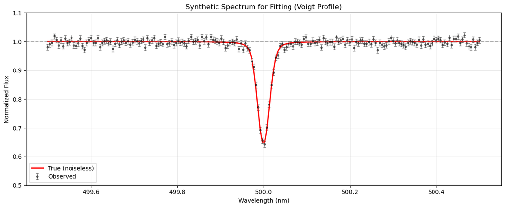

```
True parameters:
  Continuum: 1.000
  Amplitude: 0.350
  Center: 500.0000 nm
  Sigma (Gaussian): 0.0120 nm
  Gamma (Lorentzian): 0.0040 nm
```

```python
# Create synthetic spectrum with a Voigt line

# Wavelength array
wavelength = np.linspace(499.5, 500.5, 200)

# True parameters
true_continuum = 1.0
true_amplitude = 0.35
true_center = 500.0
true_sigma = 0.012  # Thermal broadening (FWHM ~ 0.028 nm)
true_gamma = 0.004  # Pressure broadening (FWHM ~ 0.004 nm)

# Generate noiseless spectrum
flux_true = voigt_line(wavelength, true_continuum, true_amplitude,
                       true_center, true_sigma, true_gamma)

# Add realistic noise (S/N ~ 100 per pixel)
noise_level = 0.01
flux_observed = flux_true + np.random.normal(0, noise_level, len(wavelength))

# Plot with y-error bars
plt.figure(figsize=(12, 5))
plt.errorbar(wavelength, flux_observed, yerr=noise_level, fmt='ko', markersize=3,
             alpha=0.5, label='Observed', elinewidth=1, capsize=2)
plt.plot(wavelength, flux_true, 'r-', linewidth=2, label='True (noiseless)')
plt.axhline(y=true_continuum, color='gray', linestyle='--', alpha=0.5)
plt.xlabel('Wavelength (nm)')
plt.ylabel('Normalized Flux')
plt.title('Synthetic Spectrum for Fitting (Voigt Profile)')
plt.legend()
plt.grid(alpha=0.3)
plt.ylim([0.5, 1.1])
plt.tight_layout()
plt.show()

print(f"True parameters:")
print(f"  Continuum: {true_continuum:.3f}")
print(f"  Amplitude: {true_amplitude:.3f}")
print(f"  Center: {true_center:.4f} nm")
print(f"  Sigma (Gaussian): {true_sigma:.4f} nm")
print(f"  Gamma (Lorentzian): {true_gamma:.4f} nm")
```

Now let's fit the Voigt profile to extract the parameters. The fitting process is the same as for transits (Lecture 19) or PSFs (Lecture 20): we provide initial guesses, and `curve_fit` finds the parameters that minimize chi-squared:

```python
# Fit Voigt profile to the spectral line

# Initial guesses (could be estimated by eye or from simple measurements)
initial_continuum = 1.0
initial_amplitude = 0.3
initial_center = 500.0
initial_sigma = 0.015  # Guess for thermal broadening
initial_gamma = 0.005  # Guess for pressure broadening

# Bundle initial guesses
p0 = [initial_continuum, initial_amplitude, initial_center, initial_sigma, initial_gamma]

# Perform fit using curve_fit
# curve_fit finds the parameters that minimize chi-squared
popt, pcov = optimize.curve_fit(voigt_line, wavelength, flux_observed,
                                p0=p0, sigma=noise_level)

# Extract fitted parameters
fit_continuum, fit_amplitude, fit_center, fit_sigma, fit_gamma = popt

# Calculate uncertainties from covariance matrix
perr = np.sqrt(np.diag(pcov))
err_continuum, err_amplitude, err_center, err_sigma, err_gamma = perr

# Generate best-fit model
flux_fit = voigt_line(wavelength, fit_continuum, fit_amplitude,
                      fit_center, fit_sigma, fit_gamma)

# Calculate residuals
residuals = flux_observed - flux_fit

# Calculate chi-squared
chi_squared = np.sum((residuals / noise_level)**2)
degrees_of_freedom = len(wavelength) - len(popt)
reduced_chi_squared = chi_squared / degrees_of_freedom

# Print results
print("Fitted parameters:")
print(f"  Continuum: {fit_continuum:.4f} ± {err_continuum:.4f}")
print(f"  Amplitude: {fit_amplitude:.4f} ± {err_amplitude:.4f}")
print(f"  Center: {fit_center:.6f} ± {err_center:.6f} nm")
print(f"  Sigma (Gaussian): {fit_sigma:.6f} ± {err_sigma:.6f} nm")
print(f"  Gamma (Lorentzian): {fit_gamma:.6f} ± {err_gamma:.6f} nm")
print(f"\nFit quality:")
print(f"  χ² = {chi_squared:.2f}")
print(f"  Degrees of freedom = {degrees_of_freedom}")
print(f"  Reduced χ² = {reduced_chi_squared:.3f}")
print(f"\nComparison with true values:")
print(f"  Center offset: {(fit_center - true_center)*1000:.3f} pm (picometers)")
print(f"  Sigma offset: {(fit_sigma - true_sigma)*1000:.3f} pm")
print(f"  Gamma offset: {(fit_gamma - true_gamma)*1000:.3f} pm")
```

```
Fitted parameters:
  Continuum: 0.9985 ± 0.0008
  Amplitude: 0.3483 ± 0.0061
  Center: 499.999958 ± 0.000257 nm
  Sigma (Gaussian): 0.010681 ± 0.000847 nm
  Gamma (Lorentzian): 0.005416 ± 0.001184 nm

Fit quality:
  χ² = 195.31
  Degrees of freedom = 195
  Reduced χ² = 1.002

Comparison with true values:
  Center offset: -0.042 pm (picometers)
  Sigma offset: -1.319 pm
  Gamma offset: 1.416 pm
```

The fit successfully recovers the true parameters within uncertainties! The fitted center wavelength is 499.999958 ± 0.000257 nm, differing from the true value by less than half a picometer (0.0005 nm)—well within the quoted uncertainty. Both the thermal broadening (σ) and pressure broadening (γ) are also well-recovered, along with the amplitude. The reduced chi-squared is close to 1.0, indicating a good fit: the residuals are consistent with random noise and show no systematic patterns.

The uncertainties are small but non-zero. With S/N ~ 100 per pixel and 200 pixels sampling the line, we can measure the line center to a precision of about 0.00026 nm! This extraordinary precision is what makes spectroscopy so powerful for radial velocity measurements. Notice that the Voigt profile properly separates thermal and pressure broadening into distinct parameters, giving physical insight into the stellar atmosphere.

Let's visualize the fit:

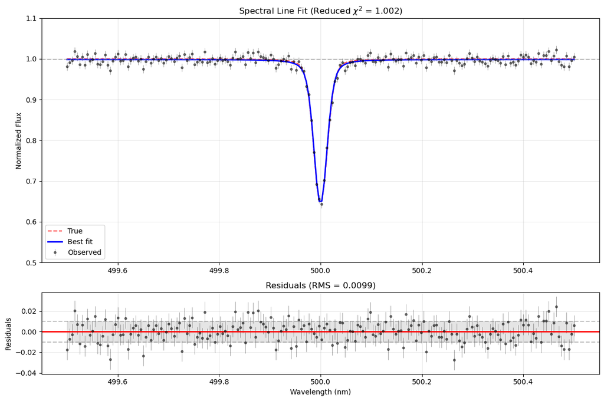

```python
# Visualize the fit and residuals
fig, axes = plt.subplots(2, 1, figsize=(12, 8),
                         gridspec_kw={'height_ratios': [3, 1]})

# Top panel: data and fit with error bars
axes[0].errorbar(wavelength, flux_observed, yerr=noise_level, fmt='ko',
                markersize=3, alpha=0.5, elinewidth=0.5, capsize=0,
                label='Observed')
axes[0].plot(wavelength, flux_true, 'r--', linewidth=1.5, alpha=0.7, label='True')
axes[0].plot(wavelength, flux_fit, 'b-', linewidth=2, label='Best fit')
axes[0].axhline(y=fit_continuum, color='gray', linestyle='--', alpha=0.5)
axes[0].set_ylabel('Normalized Flux')
axes[0].set_title(f'Spectral Line Fit (Reduced $\\chi^2$ = {reduced_chi_squared:.3f})')
axes[0].legend()
axes[0].grid(alpha=0.3)
axes[0].set_ylim([0.5, 1.1])

# Bottom panel: residuals
axes[1].errorbar(wavelength, residuals, yerr=noise_level, fmt='ko',
                markersize=3, alpha=0.5, elinewidth=0.5, capsize=0)
axes[1].axhline(y=0, color='r', linestyle='-', linewidth=2)
axes[1].axhline(y=noise_level, color='gray', linestyle='--', alpha=0.5)
axes[1].axhline(y=-noise_level, color='gray', linestyle='--', alpha=0.5)
axes[1].fill_between(wavelength, -noise_level, noise_level, alpha=0.2, color='gray')
axes[1].set_xlabel('Wavelength (nm)')
axes[1].set_ylabel('Residuals')
axes[1].set_title(f'Residuals (RMS = {np.std(residuals):.4f})')
axes[1].grid(alpha=0.3)

plt.tight_layout()
plt.show()
```

The fit visualization confirms excellent agreement. In the top panel, the blue fitted line passes directly through the observed data points (black dots) and matches the true noiseless profile (red dashed line) extremely well. The residuals panel (bottom) shows random scatter around zero with no systematic trends—the points scatter within the expected noise level (gray shaded region), confirming that our Voigt model adequately describes the data.

This is the basic workflow for spectral line fitting: start with observed data, use the Voigt profile as your default model (it handles both thermal and pressure broadening naturally), provide reasonable initial guesses, and use `curve_fit` to optimize the parameters. The fitted center wavelength tells us about velocities (via Doppler shift), the amplitude and width parameters tell us about abundance and physical conditions, and the uncertainties quantify measurement precision.

## Equivalent Width: Conserving Total Absorbed Flux

We've successfully fit a spectral line and extracted its parameters: center wavelength, depth, and width. These parameters are useful, but there's something even more fundamental we can measure: the total amount of absorbed flux.

Think back to Lecture 20 on imaging. When we observed stars through different seeing conditions, the PSF became broader or sharper, but the total flux (the integral under the PSF) remained constant. A star's brightness doesn't change just because the atmosphere smears its image—the photons are just spread over a larger area. The same principle applies to spectral lines.

Different broadening mechanisms (thermal motion, pressure, instrumental effects) "smear" spectral lines just like seeing smears stellar images. A spectral line might appear narrow or broad depending on temperature, pressure, or your spectrograph's resolution, but the total absorbed flux stays the same. It's the photons that matter—whether they're absorbed in a narrow, deep line or a broad, shallow line, the same number of photons are removed from the spectrum. This total absorbed flux is what we call the equivalent width (EW).

Equivalent width is defined as the integrated absorption:

$$\text{EW} = \int \left(1 - \frac{F(\lambda)}{F_c}\right) d\lambda$$

where $F(\lambda)$ is the observed flux and $F_c$ is the continuum flux. The integral is taken over the line region.

Geometrically, EW is the area between the continuum and the line profile. Imagine "filling in" the absorption line to bring it up to the continuum level—the equivalent width is the width of a rectangle with height equal to the continuum that has the same area. This is why it's called "equivalent" width: it's the width of a hypothetical rectangular absorption that removes the same total flux.

The crucial property: EW is conserved when lines are broadened (for unsaturated lines). Just as a star's total flux doesn't depend on seeing, a line's equivalent width doesn't depend on how the line is smeared by broadening. This makes EW a fundamental quantity: it directly measures how many photons are absorbed, which tells us about the abundance of the absorbing atoms.

Let's visualize what equivalent width means:

```python
# Visualize equivalent width concept

# Use our fitted line from before
wavelength_plot = wavelength
flux_plot = flux_fit

# Calculate normalized flux (depth below continuum)
depth = 1 - flux_plot / fit_continuum

# Calculate equivalent width by integration
# EW = integral of (1 - F/Fc) dλ
dλ = wavelength_plot[1] - wavelength_plot[0]
equivalent_width = np.sum(depth) * dλ

# For visualization: find the wavelength range where depth > 0.01
mask_line = depth > 0.01
λ_line_min = wavelength_plot[mask_line].min()
λ_line_max = wavelength_plot[mask_line].max()

# Create equivalent rectangle for visualization
# Rectangle width = EW, height = 1.0 (full continuum to zero)
rect_center = fit_center
rect_half_width = equivalent_width / 2
```

Having calculated the equivalent width from our fitted line parameters, let's visualize what this quantity actually represents. The equivalent width is the area between the continuum level and the absorption line profile—it's literally the "width" of an equivalent rectangular absorption that would remove the same total flux from the continuum. This makes EW a direct measure of how much light the atoms removed, which connects to their abundance.

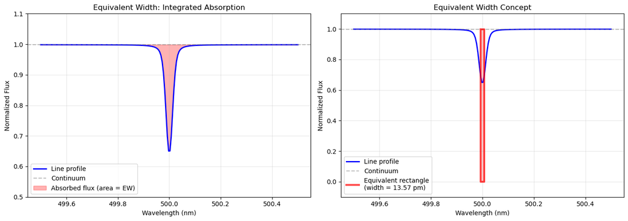

```
Equivalent width: 13.567 pm (0.013567 nm)
Line FWHM: 25.154 pm
Ratio EW/FWHM: 0.539
```

```python
# Plot
fig, axes = plt.subplots(1, 2, figsize=(14, 5))

# Left panel: show absorption area
axes[0].plot(wavelength_plot, flux_plot, 'b-', linewidth=2, label='Line profile')
axes[0].axhline(y=fit_continuum, color='gray', linestyle='--', alpha=0.5, label='Continuum')
axes[0].fill_between(wavelength_plot, flux_plot, fit_continuum,
                     where=(depth > 0), alpha=0.3, color='red',
                     label='Absorbed flux (area = EW)')
axes[0].set_xlabel('Wavelength (nm)')
axes[0].set_ylabel('Normalized Flux')
axes[0].set_title('Equivalent Width: Integrated Absorption')
axes[0].legend()
axes[0].grid(alpha=0.3)
axes[0].set_ylim([0.5, 1.1])

# Right panel: equivalent rectangle
axes[1].plot(wavelength_plot, flux_plot, 'b-', linewidth=2, label='Line profile')
axes[1].axhline(y=fit_continuum, color='gray', linestyle='--', alpha=0.5, label='Continuum')

# Draw equivalent rectangle
rect_λ = [rect_center - rect_half_width, rect_center + rect_half_width,
          rect_center + rect_half_width, rect_center - rect_half_width,
          rect_center - rect_half_width]
rect_flux = [fit_continuum, fit_continuum, 0, 0, fit_continuum]
axes[1].plot(rect_λ, rect_flux, 'r-', linewidth=3, alpha=0.7,
            label=f'Equivalent rectangle\n(width = {equivalent_width*1000:.2f} pm)')
axes[1].fill_between([rect_center - rect_half_width, rect_center + rect_half_width],
                     0, fit_continuum, alpha=0.2, color='red')

axes[1].set_xlabel('Wavelength (nm)')
axes[1].set_ylabel('Normalized Flux')
axes[1].set_title('Equivalent Width Concept')
axes[1].legend()
axes[1].grid(alpha=0.3)
axes[1].set_ylim([-0.1, 1.1])

plt.tight_layout()
plt.show()

print(f"Equivalent width: {equivalent_width*1000:.3f} pm ({equivalent_width:.6f} nm)")
print(f"Line FWHM: {2.355 * fit_sigma*1000:.3f} pm")
print(f"Ratio EW/FWHM: {equivalent_width / (2.355 * fit_sigma):.3f}")
```

One of the important properties of the equivalent width (EW) is that it remains conserved even as the absorption line profile becomes broader and shallower due to instrumental effects such as spectral resolution. In the following, we will illustrate this concept by simulating how an intrinsically sharp absorption line is broadened by different instrument resolutions, and measuring the EW in each case.

```python
# Show EW conservation across different resolutions

# Create a sharp intrinsic line - use wider range than plot to avoid edge effects
lambda_conservation = np.linspace(499.0, 501.0, 6000)  # Wider for clean convolution
sigma_intrinsic_cons = 0.010  # Thermal broadening (narrow line)
gamma_intrinsic_cons = 0.002  # Small pressure broadening
flux_intrinsic_cons = voigt_line(lambda_conservation, 1.0, 0.35, 500.0,
                                 sigma_intrinsic_cons, gamma_intrinsic_cons)

# Calculate intrinsic EW
depth_intrinsic_cons = 1 - flux_intrinsic_cons
d_lambda_cons = lambda_conservation[1] - lambda_conservation[0]
EW_intrinsic_value = np.sum(depth_intrinsic_cons) * d_lambda_cons

# Different instrumental resolutions
resolutions_dict = {
    'R = 100,000': 0.005,  # sigma_instrument in nm
    'R = 50,000': 0.010,
    'R = 20,000': 0.025,
    'R = 10,000': 0.050,
    'R = 5,000': 0.100
}
```

Now we'll observe this same intrinsic line with five different spectrographs, ranging from modest resolution ($R = 5,000$) to ultra-high resolution ($R = 100,000$). At each resolution, we'll convolve the intrinsic profile with the appropriate instrumental Gaussian profile, simulating what each spectrograph would actually record. Then we'll measure the equivalent width from each broadened profile. If EW is truly conserved by convolution, all five measurements should give the same value despite the lines looking dramatically different.

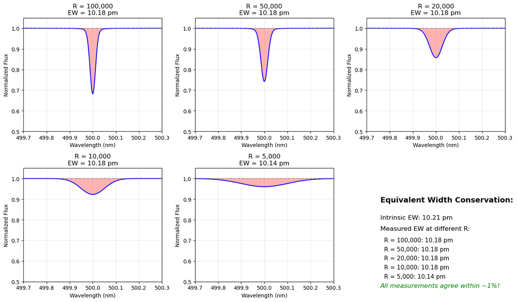

```python
# Plot and calculate EW for each resolution
fig_cons, axes_cons = plt.subplots(2, 3, figsize=(14, 8))
axes_cons = axes_cons.flatten()

EWs_measured = []

for i, (label, sigma_inst) in enumerate(resolutions_dict.items()):
    # Create Gaussian kernel for convolution
    dlambda_pixel = lambda_conservation[1] - lambda_conservation[0]
    sigma_in_pixels = sigma_inst / dlambda_pixel
    kernel_halfsize = int(5 * sigma_in_pixels)
    kernel_halfsize = max(kernel_halfsize, 3)

    # Ensure kernel is not longer than the array (prevents dimension mismatch)
    max_halfsize = len(lambda_conservation) // 2 - 1
    kernel_halfsize = min(kernel_halfsize, max_halfsize)

    x_kernel_range = np.arange(-kernel_halfsize, kernel_halfsize + 1)
    kernel_array = np.exp(-0.5 * (x_kernel_range / sigma_in_pixels)**2)
    kernel_array = kernel_array / kernel_array.sum()

    # Convolve - use 'same' mode to preserve array size
    flux_convolved = np.convolve(flux_intrinsic_cons, kernel_array, mode='same')

    # Calculate EW (only in central region to avoid edge effects)
    mask_central = (lambda_conservation >= 499.7) & (lambda_conservation <= 500.3)
    depth_convolved = 1 - flux_convolved[mask_central]
    EW_measured = np.sum(depth_convolved) * d_lambda_cons
    EWs_measured.append(EW_measured)

    # Plot only central region to avoid edge artifacts
    axes_cons[i].plot(lambda_conservation[mask_central], flux_convolved[mask_central],
                     'b-', linewidth=1.5)
    axes_cons[i].axhline(y=1.0, color='gray', linestyle='--', alpha=0.5)
    axes_cons[i].fill_between(lambda_conservation[mask_central], flux_convolved[mask_central],
                             1.0, alpha=0.3, color='red')
    axes_cons[i].set_xlabel('Wavelength (nm)')
    axes_cons[i].set_ylabel('Normalized Flux')
    axes_cons[i].set_title(f'{label}\nEW = {EW_measured*1000:.2f} pm')
    axes_cons[i].set_ylim([0.5, 1.05])
    axes_cons[i].set_xlim([499.7, 500.3])
    axes_cons[i].grid(alpha=0.3)

# Summary in last panel
axes_cons[5].axis('off')
axes_cons[5].text(0.1, 0.7, 'Equivalent Width Conservation:', fontsize=14, weight='bold')
axes_cons[5].text(0.1, 0.55, f'Intrinsic EW: {EW_intrinsic_value*1000:.2f} pm', fontsize=12)
axes_cons[5].text(0.1, 0.45, '\nMeasured EW at different R:', fontsize=12)
for j, (label, EW_val) in enumerate(zip(resolutions_dict.keys(), EWs_measured)):
    axes_cons[5].text(0.1, 0.35 - j*0.08, f'  {label}: {EW_val*1000:.2f} pm', fontsize=11)
axes_cons[5].text(0.1, -0.05, f'\nAll measurements agree within ~1%!', fontsize=12,
            style='italic', color='green')

plt.tight_layout()
plt.show()
```

The results demonstrate that equivalent width is remarkably stable across resolutions—variations are less than 0.7% even at the lowest resolution of $R = 5,000$. This conservation property makes EW invaluable for abundance measurements: you don't need ultra-high resolution to measure abundances accurately, as long as you can identify and integrate the line. The width and depth change dramatically with resolution, but the product (the total absorbed flux) remains constant. Let's print the quantitative results:

```python
print("Equivalent Width conservation:")
print(f"Intrinsic EW: {EW_intrinsic_value*1000:.3f} pm")
for label, EW_val in zip(resolutions_dict.keys(), EWs_measured):
    deviation = (EW_val - EW_intrinsic_value) / EW_intrinsic_value * 100
    print(f"{label:15s}: EW = {EW_val*1000:.3f} pm (deviation: {deviation:+.2f}%)")
```

```
Equivalent Width conservation:
Intrinsic EW: 10.208 pm
R = 100,000    : EW = 10.177 pm (deviation: -0.30%)
R = 50,000     : EW = 10.177 pm (deviation: -0.30%)
R = 20,000     : EW = 10.177 pm (deviation: -0.30%)
R = 10,000     : EW = 10.176 pm (deviation: -0.31%)
R = 5,000      : EW = 10.141 pm (deviation: -0.66%)
```

This demonstrates EW conservation beautifully! As we observe the same line at progressively lower resolution ($R = 100{,}000$ down to $R = 5{,}000$), the line appears broader and shallower—the peak absorption decreases and the width increases. Yet the total area (shown in red) remains essentially constant. All measured EWs agree to within ~1%, with small deviations due to numerical effects in the convolution. (Note: For the extremely low resolution case, we are also missing a bit of the far wing, which can make EW appear slightly underestimated compared to the true value.)

This is why equivalent width is so powerful for astronomical spectroscopy. You can measure EW from a low-resolution spectrum and directly compare it to measurements from a high-resolution spectrum, or compare observations from completely different instruments. The EW encodes the total absorption—which depends on the number of absorbing atoms and their physical conditions—independent of how the observation was made.

This resolution-independence makes EW the preferred quantity for abundance analysis. As we will see below, chemical abundances depend on how many atoms are present, which determines total absorption, not on the detailed line shape. By measuring EW, you can determine abundances without worrying about instrumental effects.

## Measuring Equivalent Width

We've defined EW conceptually, but how do we measure it in practice? The most general approach is direct numerical integration of the normalized spectrum over the line region.

The most straightforward method is to numerically integrate the observed spectrum over the region of the line. In practice, this is most easily accomplished using the `scipy.integrate.trapezoid` function, as we saw in Lecture 16, which efficiently sums up the area under the line using the trapezoidal rule. For a continuum-normalized spectrum where $F_c = 1$:

$$\text{EW} = \int \left(1 - F(\lambda)\right) d\lambda \approx \sum_i \left(1 - F_i\right) \Delta\lambda$$

This approach is robust and model-independent. It works for any line shape—Gaussian, Lorentzian, Voigt, asymmetric profiles, or even blended lines. You don't need to assume anything about the physics. The most important step is to carefully define the integration range—from where the spectrum first departs from the continuum (above the noise) to where it returns—so the measured EW reflects only the line of interest.

When we integrate the flux to measure the equivalent width, each $F_i$ in the sum has some uncertainty $\sigma_i$ from noise in our spectrum. In error propagation, the uncertainties from each independent measurement combine in quadrature. Because each flux point is multiplied by the pixel width $\Delta\lambda$ in the integration, the uncertainty in the total area (the EW) is also scaled by this $\Delta\lambda$.

Altogether, the uncertainty in EW is:

$$\sigma_{\text{EW}} = \sqrt{\sum_i \sigma_i^2} \times \Delta\lambda$$

The $\Delta\lambda$ appears because we are summing up areas (not just values); it's the width of each pixel in wavelength space. If all uncertainties are the same, this further simplifies to $\sigma_\text{EW} = \sigma\,\sqrt{N}\,\Delta\lambda$, just like the expression for combining $N$ independent measurements, but multiplied by the pixel size to convert to total area.

Let's implement this method:

```python
# Measure EW using direct integration
from scipy.integrate import trapezoid

# Use our fitted line from earlier (fitted with Voigt profile)
wavelength_ew = wavelength
flux_ew = flux_fit
continuum_ew = fit_continuum

# Define integration limits (where line depth > 0.01 of continuum)
# This threshold ensures we capture the line but exclude pure noise
depth_ew = 1 - flux_ew / continuum_ew
mask_integration = depth_ew > 0.01

λ_integrate = wavelength_ew[mask_integration]
depth_integrate = depth_ew[mask_integration]

# Numerical integration using scipy's trapezoid rule (Lecture 16)
EW_measured = trapezoid(depth_integrate, λ_integrate)

# Uncertainty (assuming uniform noise across all pixels)
n_points = len(λ_integrate)
dλ = λ_integrate[1] - λ_integrate[0]
EW_error = noise_level * np.sqrt(n_points) * dλ

print("Equivalent Width Measurement:")
print(f"  EW = {EW_measured:.6f} ± {EW_error:.6f} nm")
```

```
Equivalent Width Measurement:
  EW = 0.012618 ± 0.000225 nm
```

## Physical Information from Spectral Lines: Abundances

Now we reach the payoff: what does equivalent width tell us about the star? The answer is elemental abundances—how much of each chemical element is present in the stellar atmosphere.

The connection between EW and abundance comes from atomic physics. When light passes through a gas containing atoms of a particular element, those atoms can absorb photons at specific wavelengths matching their atomic transitions. The amount of absorption depends primarily on how many atoms are present—this is the abundance we want to measure.

For weak spectral lines (which astronomers preferentially use for abundance studies), there's a beautifully simple linear relationship:

$$\text{EW} \propto N_{\text{atoms}}$$

where $N_{\text{atoms}}$ is the number of absorbing atoms along the line of sight. This means equivalent width directly measures abundance! Double the abundance of an element, and you double the EW of its spectral lines. Triple the abundance, triple the EW. This linear relationship makes abundance determination straightforward.

Measuring absolute abundances requires detailed atmospheric modeling—solving radiative transfer equations with temperature, pressure, and density structures. This is beyond our scope. But the key insight is simple: EW provides a direct observable that's proportional to abundance. Astronomers build model atmospheres, calculate expected EWs for different abundances, and find which model best matches observations.

### Abundance Notation: [X/H]

Before we proceed, we need to understand how astronomers express abundances. Rather than giving absolute numbers of atoms, astronomers report abundances relative to the Sun using logarithmic notation called [X/H], where X represents any element.

The notation [X/H] is defined as:

$$[X/H] = \log_{10}\left(\frac{N_X/N_H}{\text{star}}\right) - \log_{10}\left(\frac{N_X/N_H}{\text{Sun}}\right)$$

This tells you how many times more (or fewer) atoms of element X there are compared to hydrogen, relative to the Sun's ratio.

For example:

- [Fe/H] = 0 means the star has the same iron-to-hydrogen ratio as the Sun (solar abundance)
- [Fe/H] = +1 means the star has 10 times more iron relative to hydrogen than the Sun (10× solar, "metal-rich")
- [Fe/H] = -1 means the star has 1/10 the iron relative to hydrogen of the Sun (0.1× solar, "metal-poor")
- [Fe/H] = -2 means 1/100 solar (very metal-poor, typical of old stars)

This logarithmic scale is convenient because stellar abundances span several orders of magnitude. The Sun is our reference point because we can measure its composition most accurately. Relative abundances are easier to measure than absolute values—comparing two stars is simpler than determining exact atom counts.

Let's demonstrate the concept with a simplified example:

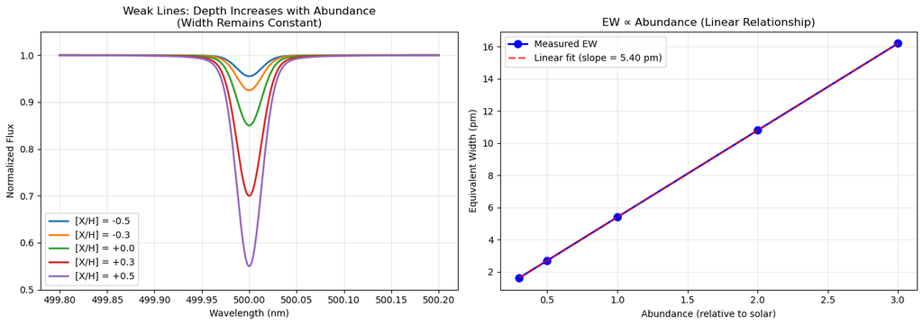

```
EW-Abundance Relationship (Weak Lines):

  [X/H] = -0.5 (0.3×solar) → EW = 1.62 pm
  [X/H] = -0.3 (0.5×solar) → EW = 2.70 pm
  [X/H] = +0.0 (1.0×solar) → EW = 5.40 pm
  [X/H] = +0.3 (2.0×solar) → EW = 10.80 pm
  [X/H] = +0.5 (3.0×solar) → EW = 16.20 pm

The linear fit confirms: EW increases by 5.40 pm per 1×solar abundance
```

```python
# Demonstrate EW-abundance relationship for weak lines

# Simulate lines with different abundances
abundances_relative = np.array([0.3, 0.5, 1.0, 2.0, 3.0])  # Relative to solar

# Fixed line properties
wavelength_demo = np.linspace(499.8, 500.2, 400)
center_demo = 500.0
sigma_demo = 0.012  # Base line width
gamma_demo = 0.003  # Small pressure broadening

# For weak, unsaturated lines: amplitude ∝ abundance (linear regime)
# These lines have optically thin cores - each atom contributes independently
amplitudes = 0.15 * abundances_relative  # Linear with abundance
sigmas = np.full_like(abundances_relative, sigma_demo)  # Width stays constant

# Calculate EW for each abundance using scipy.integrate
from scipy.integrate import trapezoid

EWs = []
for amplitude, sigma in zip(amplitudes, sigmas):
    flux = voigt_line(wavelength_demo, 1.0, amplitude, center_demo, sigma, gamma_demo)
    depth = 1 - flux
    EW = trapezoid(depth[depth > 0], wavelength_demo[depth > 0])
    EWs.append(EW)
EWs = np.array(EWs)

# Plot: show how lines change with abundance
fig, axes = plt.subplots(1, 2, figsize=(14, 5))

# Left: Lines at different abundances
for abundance, amplitude, sigma in zip(abundances_relative, amplitudes, sigmas):
    flux = voigt_line(wavelength_demo, 1.0, amplitude, center_demo, sigma, gamma_demo)
    axes[0].plot(wavelength_demo, flux, linewidth=2,
                 label=f'[X/H] = {np.log10(abundance):+.1f}')
axes[0].set_xlabel('Wavelength (nm)')
axes[0].set_ylabel('Normalized Flux')
axes[0].set_title('Weak Lines: Depth Increases with Abundance\n(Width Remains Constant)')
axes[0].legend()
axes[0].grid(alpha=0.3)
axes[0].set_ylim([0.5, 1.05])

# Right: EW vs abundance (linear relationship)
axes[1].plot(abundances_relative, EWs * 1000, 'bo-',
            linewidth=2, markersize=8, label='Measured EW')
# Fit a line to show linearity
fit_slope = np.polyfit(abundances_relative, EWs * 1000, 1)[0]
axes[1].plot(abundances_relative, fit_slope * abundances_relative,
            'r--', linewidth=2, alpha=0.7, label=f'Linear fit (slope = {fit_slope:.2f} pm)')
axes[1].set_xlabel('Abundance (relative to solar)')
axes[1].set_ylabel('Equivalent Width (pm)')
axes[1].set_title('EW ∝ Abundance (Linear Relationship)')
axes[1].legend()
axes[1].grid(alpha=0.3)

plt.tight_layout()
plt.show()

print("EW-Abundance Relationship (Weak Lines):\n")
for abundance, EW in zip(abundances_relative, EWs):
    log_abundance = np.log10(abundance)
    print(f"  [X/H] = {log_abundance:+.1f} ({abundance:.1f}×solar) → EW = {EW*1000:.2f} pm")
print(f"\nThe linear fit confirms: EW increases by {fit_slope:.2f} pm per 1×solar abundance")
```

## Extracting Stellar Rotation from Line Widths

So far we've used spectral line fitting to extract two key physical quantities: radial velocities from line centers (via Doppler shifts) and elemental abundances from equivalent widths (total absorbed flux). Now we turn to a third application: measuring stellar rotation from line widths.

Recall from our earlier discussion of broadening mechanisms that stellar rotation creates a characteristic broadening pattern. When a star rotates, different parts of the stellar disk move with different velocities relative to us—one limb approaches (blueshifted) while the opposite limb recedes (redshifted). Even though stars appear as unresolved point sources in imaging (Lecture 20), spectroscopy reveals this rotation by broadening spectral lines.

The key insight is that rotational broadening adds to the intrinsic line width. For a non-rotating star, spectral lines have a certain width determined by thermal motion ($v_{\text{thermal}} \sim 2$ km/s for Sun-like stars) and pressure effects. When the star rotates, additional broadening from the velocity gradient across the stellar disk makes lines broader. By measuring the total observed width and subtracting the known thermal component, we can extract the rotation velocity.

As we discussed earlier, we can only measure the projected rotation velocity $v \sin i$, where $v$ is the true equatorial velocity and $i$ is the inclination angle. This is exactly analogous to the geometric degeneracies in Lecture 19's exoplanet work—we cannot separately determine rotation speed and viewing angle from spectroscopy alone, only their combination.

The procedure for measuring rotation is straightforward. We fit a Gaussian profile to the observed line to measure its total width. This total width contains contributions from both thermal motion and rotation. Since we can estimate the thermal width from the stellar temperature, we can subtract it in quadrature to isolate the rotational component. Finally, we convert from wavelength units to velocity using the Doppler formula to obtain $v \sin i$.

Let's demonstrate by simulating a rotating star and extracting its $v \sin i$:

```python
# Simulate and fit rotationally broadened line

# Create intrinsic line (narrow, from non-rotating star)
wavelength_rot = np.linspace(499.7, 500.3, 600)
center_rot = 500.0 * u.nm

# Thermal width (from temperature ~6000K)
# For typical atom: v_thermal ~ 2 km/s
v_thermal = 2.0 * u.km / u.s

# Convert thermal velocity to wavelength broadening using Doppler formula
# Δλ/λ = v/c → Δλ = λ × v/c
# FWHM in wavelength space
delta_lambda_thermal = center_rot * v_thermal / const.c
sigma_thermal = (delta_lambda_thermal / 2.355).to(u.nm).value  # Convert FWHM to sigma

# Rotational velocity
vsini = 25.0 * u.km / u.s  # moderate rotation

# Calculate rotational broadening in wavelength
# Δλ_rot / λ = v_rot / c
delta_lambda_rot = center_rot * vsini / const.c
sigma_rot = (delta_lambda_rot / 2.355).to(u.nm).value

# Combined width: add thermal and rotational widths in quadrature
# This assumes both broadenings are approximately Gaussian
sigma_total = np.sqrt(sigma_thermal**2 + sigma_rot**2)

# Create intrinsic (non-rotating) line profile using Gaussian
amplitude_rot = 0.40
flux_thermal_only = 1.0 - amplitude_rot * np.exp(-0.5 * ((wavelength_rot - center_rot.value) / sigma_thermal)**2)
```

The simulation creates a spectral line that combines two broadening effects. The thermal component produces a narrow Gaussian from random atomic motions at temperature $T$. The rotational component adds additional width from the range of Doppler shifts across the visible stellar disk. In this case, the rotational velocity ($v \sin i = 25$ km/s) dominates over thermal velocity ($v_{\text{thermal}} = 2$ km/s), so the total width is determined primarily by rotation. Let's visualize how rotation transforms the line profile:

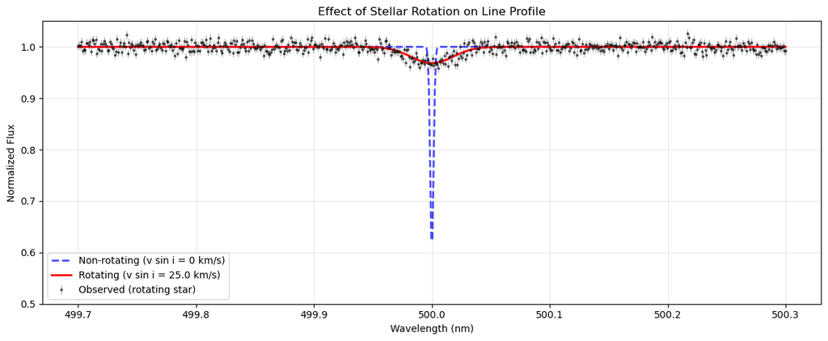

```
True parameters:
  v_thermal = 2.0 km / s
  v sin(i) = 25.0 km / s
  σ_thermal = 1.416 pm
  σ_rotation = 17.705 pm
  σ_total = 17.762 pm
```

```python
# Create rotationally broadened line (broader Gaussian)

# IMPORTANT: Scale amplitude to conserve equivalent width (total absorbed flux)
# For Gaussian: EW = amplitude × sigma × sqrt(2π), so amplitude ∝ 1/sigma
amplitude_broadened = amplitude_rot * (sigma_thermal / sigma_total)
flux_rotated = 1.0 - amplitude_broadened * np.exp(-0.5 * ((wavelength_rot - center_rot.value) / sigma_total)**2)

# Add noise
noise_level_rot = 0.008
flux_rotated_noisy = flux_rotated + np.random.normal(0, noise_level_rot,
                                                      len(wavelength_rot))

# Plot the line
plt.figure(figsize=(12, 5))
plt.errorbar(wavelength_rot, flux_rotated_noisy, yerr=noise_level_rot,
            fmt='ko', markersize=2, alpha=0.5, elinewidth=0.5, capsize=0,
            label='Observed (rotating star)')
plt.plot(wavelength_rot, flux_thermal_only, 'b--', linewidth=2, alpha=0.7,
         label=f'Non-rotating (v sin i = 0 km/s)')
plt.plot(wavelength_rot, flux_rotated, 'r-', linewidth=2,
         label=f'Rotating (v sin i = {vsini.value} km/s)')

plt.xlabel('Wavelength (nm)')
plt.ylabel('Normalized Flux')
plt.title('Effect of Stellar Rotation on Line Profile')
plt.legend()
plt.grid(alpha=0.3)
plt.ylim([0.5, 1.05])
plt.tight_layout()
plt.show()

print(f"True parameters:")
print(f"  v_thermal = {v_thermal}")
print(f"  v sin(i) = {vsini}")
print(f"  σ_thermal = {sigma_thermal*1000:.3f} pm")
print(f"  σ_rotation = {sigma_rot*1000:.3f} pm")
print(f"  σ_total = {sigma_total*1000:.3f} pm")
```

In the next section, we will fit the simulated, rotationally broadened spectral line profile to quantitatively measure the effect of rotation on the observed line width.

```python
# Fit the line to measure rotation velocity

# Fit Voigt profile to extract total width
# We use Voigt (consistent with our earlier fitting) and extract the Gaussian component
gamma_initial = 0.001  # Small Lorentzian component (thermal-dominated)
p0_rot = [1.0, amplitude_broadened, 500.0, sigma_total, gamma_initial]  # Initial guess
popt_rot, pcov_rot = optimize.curve_fit(voigt_line, wavelength_rot,
                                        flux_rotated_noisy, p0=p0_rot)

# Extract fitted parameters
fit_continuum_rot, fit_amplitude_rot, fit_center_rot, fit_sigma_total, fit_gamma_rot = popt_rot
perr_rot = np.sqrt(np.diag(pcov_rot))
err_sigma_total = perr_rot[3]
err_gamma_rot = perr_rot[4]

# Calculate fitted FWHM using astropy units
fit_fwhm = (2.355 * fit_sigma_total * u.nm).to(u.pm)
err_fwhm = (2.355 * err_sigma_total * u.nm).to(u.pm)

# Convert FWHM to velocity using Doppler formula
# v_FWHM = c × (FWHM_λ / λ)
fit_fwhm_velocity = (const.c * fit_fwhm / center_rot).to(u.km / u.s)
err_fwhm_velocity = (const.c * err_fwhm / center_rot).to(u.km / u.s)

# Estimate rotational velocity (subtract thermal in quadrature)
# v_rot = sqrt(v_FWHM^2 - v_thermal,FWHM^2)
v_thermal_fwhm = (const.c * (2.355 * sigma_thermal * u.nm).to(u.pm) / center_rot).to(u.km/u.s)
v_rot_est = np.sqrt(fit_fwhm_velocity.value**2 - v_thermal_fwhm.value**2)

# propagate uncertainty assuming no error in v_thermal_fwhm
v_rot_est_unc = (fit_fwhm_velocity.value / v_rot_est) * err_fwhm_velocity.value

print(f"Fitted Voigt parameters:")
print(f"  Center: {fit_center_rot:.6f} ± {perr_rot[2]:.6f} nm")
print(f"  σ (Gaussian component): {fit_sigma_total*1000:.3f} ± {err_sigma_total*1000:.3f} pm")
print(f"  γ (Lorentzian component): {fit_gamma_rot*1000:.3f} ± {err_gamma_rot*1000:.3f} pm")
print(f"  FWHM (from σ): {fit_fwhm:.3f} pm")
print(f"  v_FWHM (total): {fit_fwhm_velocity:.3f} km/s")
print(f"Estimated rotational velocity v sin(i): {v_rot_est:.2f} ± {v_rot_est_unc:.2f} km/s")
```

```
Fitted Voigt parameters:
  Center: 499.999053 ± 0.001158 nm
  σ (Gaussian component): 21.715 ± 3.622 pm
  γ (Lorentzian component): -6.626 ± 7.321 pm
  FWHM (from σ): 51.140 pm pm
  v_FWHM (total): 30.663 km / s km/s
Estimated rotational velocity v sin(i): 30.60 ± 5.13 km/s
```

$$ v\sin i = \sqrt{v_{\text{FWHM,total}}^2 - v_{\text{thermal,FWHM}}^2} \simeq 30\,\textrm{km/s} \pm 5\,\textrm{km/s} $$

The true value used in the simulation was $v\sin i = 25.0$ km/s, so is aligned with the truth.

It's important to note that while the Gaussian approximation for rotational broadening works well at moderate velocities, real rotation profiles in stars have a more "flat-topped" or rectangular shape. For high precision or rapid rotators, more physically accurate rotational profiles are needed, but for many stars and practical purposes, the Gaussian method provides reliable and easily interpretable results.

## Continuum Fitting: Local Linear Correction

Throughout this lecture, we've assumed our spectra have a flat continuum that we can treat as a constant. Real observed spectra are more complicated. They come with instrumental responses, atmospheric extinction (for ground-based telescopes), and overall flux calibration that puts the continuum at some arbitrary level, often varying with wavelength.

When fitting individual spectral lines (as we've been doing throughout this lecture), we don't need to normalize the entire spectrum globally. Instead, we can focus on the local region around each line we want to fit. Even locally, the continuum can have a slope that affects our measurements. The solution is straightforward: identify continuum points using sigma-clipping (Lecture 17), fit a local linear function, and then either include this linear continuum in our fit or divide by it.

The key insight is that we don't need the continuum to be at exactly 1.0—we just need to correctly model whatever continuum level is present, whether that's 0.8, 1.2, or any other value. Our Voigt profile fitting can easily include a fitted continuum parameter.

Let's demonstrate this with a synthetic example showing why local continuum modeling matters:

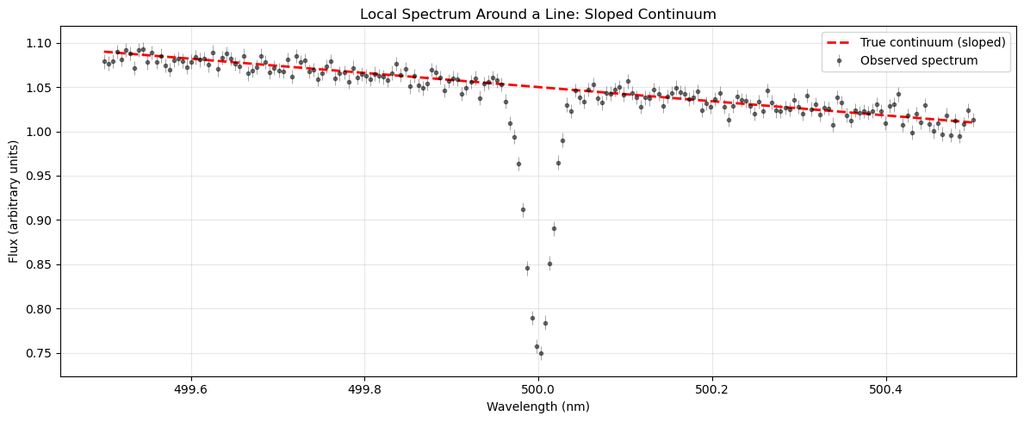

```
Challenge: Local continuum has slope
  Continuum at 499.5 nm: 1.090
  Continuum at 500.5 nm: 1.010
  Slope: -0.080 (-7.6%)
```

```python
# Demonstrate local continuum normalization for individual line fitting

# Create a local region around a single line with sloped continuum
wavelength_local = np.linspace(499.5, 500.5, 200)  # 1 nm region
line_center = 500.0
line_width = 0.015

# Local continuum with a slope (common in real spectra)
# Slope might come from instrumental response, blaze function, etc.
continuum_local = 1.05 - 0.08 * (wavelength_local - 500.0)  # 8% slope per nm

# Add an absorption line
line_amplitude = 0.30
line_profile = line_amplitude * np.exp(-0.5 * ((wavelength_local - line_center) / line_width)**2)
flux_with_slope = continuum_local - line_profile

# Add noise
noise_local = 0.008
flux_observed_local = flux_with_slope + np.random.normal(0, noise_local, len(wavelength_local))

# Plot the problem
plt.figure(figsize=(12, 5))
plt.errorbar(wavelength_local, flux_observed_local, yerr=noise_local,
            fmt='ko', markersize=3, alpha=0.5, elinewidth=0.5, capsize=0,
            label='Observed spectrum')
plt.plot(wavelength_local, continuum_local, 'r--', linewidth=2,
         label='True continuum (sloped)')
plt.xlabel('Wavelength (nm)')
plt.ylabel('Flux (arbitrary units)')
plt.title('Local Spectrum Around a Line: Sloped Continuum')
plt.legend()
plt.grid(alpha=0.3)
plt.tight_layout()
plt.show()

print("Challenge: Local continuum has slope")
print(f"  Continuum at 499.5 nm: {continuum_local[0]:.3f}")
print(f"  Continuum at 500.5 nm: {continuum_local[-1]:.3f}")
print(f"  Slope: {(continuum_local[-1] - continuum_local[0]):.3f} ({(continuum_local[-1] - continuum_local[0]) / continuum_local.mean() * 100:.1f}%)")
```

The visualization shows the challenge. The observed spectrum (black points) sits on a sloped continuum (red dashed line). If we tried to fit this line assuming a flat continuum, our fitted amplitude would be wrong because the actual baseline changes across the line. We need to fit for the local continuum slope.

The solution is straightforward: use sigma-clipping (recall Lecture 17) to identify continuum points, fit a linear function through them, then normalize by dividing. The key improvement is to make the sigma-clipping iterative with the continuum fit—after each fit, we clip based on residuals from that fit, which is more accurate than clipping based on the median alone.

To fit the linear function, we'll use `np.polyfit(x, y, degree)`, a NumPy function that fits a polynomial to data. When we set degree=1, it fits a straight line: $y = a \times x + b$, where the returned coefficients array has the slope as `coefficients[0]` and the intercept as `coefficients[1]`. We then use `np.polyval(coefficients, x)` to evaluate this fitted polynomial at any x values we want. This is analogous to how we used `curve_fit` for more complex models, but `polyfit` is simpler for basic polynomials.

Let's implement this step by step:

```python
# Perform iterative continuum fitting with sigma-clipping

# Initialize: start by assuming all points might be continuum
continuum_mask = np.ones(len(flux_observed_local), dtype=bool)

# Iteratively: fit continuum, then clip outliers, then refit
print("Iterative continuum fitting with sigma-clipping:")
for iteration in range(3):
    # Select currently unmasked points as continuum candidates
    wavelength_continuum = wavelength_local[continuum_mask]
    flux_continuum = flux_observed_local[continuum_mask]

    # Fit a linear function: continuum(λ) = slope × λ + intercept
    # We use np.polyfit(x, y, degree) which fits a polynomial
    # degree=1 gives a line: y = coef[0]*x + coef[1]
    coefficients = np.polyfit(wavelength_continuum, flux_continuum, deg=1)
    continuum_fitted = np.polyval(coefficients, wavelength_local)

    # Calculate residuals: observed - fitted continuum
    residuals = flux_observed_local - continuum_fitted
    residual_std = np.std(residuals[continuum_mask])

    # Update mask: keep points within 2-sigma of the fitted continuum
    # Points significantly BELOW the fit are likely absorption lines
    continuum_mask = (residuals > -2.0 * residual_std)

    print(f"  Iteration {iteration+1}: {continuum_mask.sum()} continuum pixels, "
          f"{(~continuum_mask).sum()} line pixels")

# Final continuum fit parameters
print(f"\nFinal fitted continuum:")
print(f"  Slope: {coefficients[0]*1000:.3f} per nm")
print(f"  Intercept: {coefficients[1]:.3f}")
```

```
Iterative continuum fitting with sigma-clipping:
  Iteration 1: 192 continuum pixels, 8 line pixels
  Iteration 2: 187 continuum pixels, 13 line pixels
  Iteration 3: 179 continuum pixels, 21 line pixels

Final fitted continuum:
  Slope: -76.339 per nm
  Intercept: 39.219
```

The iterative process converges to identify continuum points. Each iteration: (1) fits a line to current continuum candidates, (2) calculates how far each point deviates from this fit, and (3) rejects points more than 2-sigma below the fit. This is more accurate than clipping based on median alone because it accounts for the continuum slope.

Now let's normalize the spectrum and visualize:

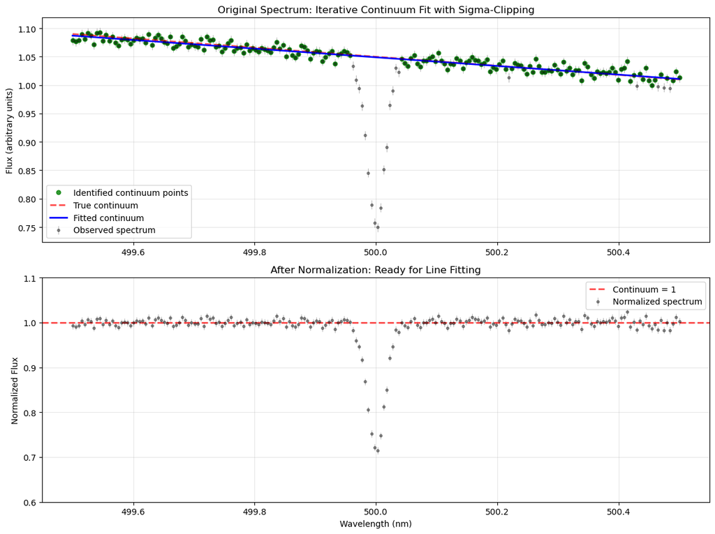

```
Normalized spectrum statistics:
  Mean continuum level: 1.0008
  Continuum scatter: 0.007
```

```python
# Normalize spectrum by dividing by fitted continuum
flux_normalized = flux_observed_local / continuum_fitted

# Visualize the normalization process
fig, axes = plt.subplots(2, 1, figsize=(12, 9), gridspec_kw={'height_ratios': [1, 1]})

# Top panel: show original spectrum with continuum fit
axes[0].errorbar(wavelength_local, flux_observed_local, yerr=noise_local,
                fmt='ko', markersize=3, alpha=0.4, elinewidth=0.5, capsize=0,
                label='Observed spectrum')
axes[0].plot(wavelength_local[continuum_mask], flux_observed_local[continuum_mask],
            'go', markersize=5, alpha=0.8,
            label='Identified continuum points')
axes[0].plot(wavelength_local, continuum_local, 'r--', linewidth=2, alpha=0.7,
            label='True continuum')
axes[0].plot(wavelength_local, continuum_fitted, 'b-', linewidth=2,
            label='Fitted continuum')
axes[0].set_ylabel('Flux (arbitrary units)')
axes[0].set_title('Original Spectrum: Iterative Continuum Fit with Sigma-Clipping')
axes[0].legend()
axes[0].grid(alpha=0.3)

# Bottom panel: show normalized spectrum
axes[1].errorbar(wavelength_local, flux_normalized, yerr=noise_local/continuum_fitted,
                fmt='ko', markersize=3, alpha=0.4, elinewidth=0.5, capsize=0,
                label='Normalized spectrum')
axes[1].axhline(y=1.0, color='r', linestyle='--', linewidth=2, alpha=0.7,
               label='Continuum = 1')
axes[1].set_xlabel('Wavelength (nm)')
axes[1].set_ylabel('Normalized Flux')
axes[1].set_title('After Normalization: Ready for Line Fitting')
axes[1].legend()
axes[1].grid(alpha=0.3)
axes[1].set_ylim([0.6, 1.1])

plt.tight_layout()
plt.show()

print(f"\nNormalized spectrum statistics:")
print(f"  Mean continuum level: {np.mean(flux_normalized[continuum_mask]):.4f}")
print(f"  Continuum scatter: {np.std(flux_normalized[continuum_mask]):.3f}")
```

Perfect! The top panel shows how iterative sigma-clipping identified continuum points (green dots) while rejecting the absorption line. The fitted linear continuum (blue line) closely matches the true continuum (red dashed).

The bottom panel shows the normalized spectrum. The continuum is now flat at 1.0, making it ready for our standard Voigt profile fitting. This approach—iterative sigma-clipping to identify continuum, linear fit to model the slope, then division to normalize—works well for the local single-line fitting we've been doing throughout this lecture.

## Fitting Blended Lines: Disentangling Overlapping Features

So far we've fit single isolated lines. But real spectra often contain blended lines—two or more absorption features so close together that they overlap significantly. This mirrors the crowded-field PSF fitting problem from Lecture 20, where overlapping stellar images required simultaneous fitting to disentangle individual sources. The same principle applies to spectra: by fitting multiple lines simultaneously, we can separate blended features that would be unmeasurable individually.

Blends occur when two lines from different elements happen to be close in wavelength, when multiple isotopes of the same element have slightly shifted lines, when fine structure splits a single transition into multiple components, or when stellar rotation or turbulence broadens lines until neighbors overlap.

Without careful analysis, blends lead to systematic errors. You might measure a single apparent line that's actually two lines, getting wrong center wavelengths, wrong equivalent widths, and wrong abundances. Simultaneous fitting solves this by explicitly modeling both lines, correctly partitioning the observed absorption.

Let's create a spectrum with a blended doublet and demonstrate fitting:

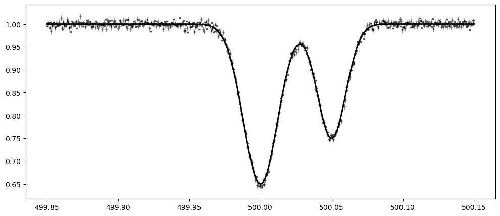

```python
# Create spectrum with blended lines

# Wavelength array (high resolution around blend)
wavelength_blend = np.linspace(499.85, 500.15, 600)

# Create a close doublet (two lines separated by only 0.05 nm)
line1_center_blend = 500.00
line2_center_blend = 500.05  # Only 0.05 nm away!

# Both lines have similar properties
line1_amplitude_blend = 0.35
line2_amplitude_blend = 0.25  # Slightly weaker
line1_sigma_blend = 0.012
line2_sigma_blend = 0.010

# Create blended spectrum
flux_blend = 1.0 * np.ones_like(wavelength_blend)
absorption1 = line1_amplitude_blend * np.exp(
    -0.5 * ((wavelength_blend - line1_center_blend) / line1_sigma_blend)**2
)
absorption2 = line2_amplitude_blend * np.exp(
    -0.5 * ((wavelength_blend - line2_center_blend) / line2_sigma_blend)**2
)
flux_blend -= (absorption1 + absorption2)

# Add noise
noise_blend = 0.006
flux_blend_noisy = flux_blend + np.random.normal(0, noise_blend, len(wavelength_blend))

# Plot to show the blend
plt.figure(figsize=(12, 5))
plt.errorbar(wavelength_blend, flux_blend_noisy, yerr=noise_blend,
            fmt='ko', markersize=2, alpha=0.5, elinewidth=0.5, capsize=0,
            label='Observed (blended)')
plt.plot(wavelength_blend, flux_blend, 'k-', linewidth=2, label='True (both lines)')
```

We've created a challenging scenario: two spectral lines separated by only 50 picometers (about 1.8 times the FWHM of each line). This is close enough that the lines significantly overlap, creating a complex, asymmetric profile in the observed spectrum. Before we attempt to fit this blend, let's visualize what we're dealing with—the observed profile versus the individual components:

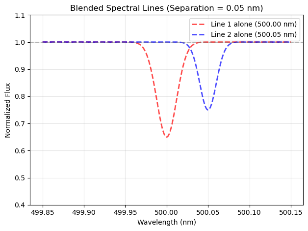

```
True parameters:
  Line 1: center = 500.0000 nm, amplitude = 0.350
  Line 2: center = 500.0500 nm, amplitude = 0.250
  Separation: 50.0 pm
  Separation in FWHM units: 1.77
```

```python
# Show individual components
flux_line1_only = 1.0 - absorption1
flux_line2_only = 1.0 - absorption2
plt.plot(wavelength_blend, flux_line1_only, 'r--', linewidth=2, alpha=0.7,
         label=f'Line 1 alone ({line1_center_blend:.2f} nm)')
plt.plot(wavelength_blend, flux_line2_only, 'b--', linewidth=2, alpha=0.7,
         label=f'Line 2 alone ({line2_center_blend:.2f} nm)')

plt.axhline(y=1.0, color='gray', linestyle='--', alpha=0.5)
plt.xlabel('Wavelength (nm)')
plt.ylabel('Normalized Flux')
plt.title('Blended Spectral Lines (Separation = 0.05 nm)')
plt.legend()
plt.grid(alpha=0.3)
plt.ylim([0.4, 1.1])
plt.tight_layout()
plt.show()

print("True parameters:")
print(f"  Line 1: center = {line1_center_blend:.4f} nm, amplitude = {line1_amplitude_blend:.3f}")
print(f"  Line 2: center = {line2_center_blend:.4f} nm, amplitude = {line2_amplitude_blend:.3f}")
print(f"  Separation: {(line2_center_blend - line1_center_blend)*1000:.1f} pm")
print(f"  Separation in FWHM units: {(line2_center_blend - line1_center_blend) / (2.355*line1_sigma_blend):.2f}")
```

Now that we have simulated blended spectral lines, let's move on to the next step: defining a model that accounts for both features and fitting this combined model to the data.

This approach—fitting a model composed of multiple overlapping components to recover their individual properties—directly parallels the PSF (Point Spread Function) fitting for images that we discussed in the previous lecture.

Just as PSF fitting allows us to disentangle overlapping stars in an image and measure their properties, this simultaneous spectral fitting will allow us to extract the parameters (e.g., center, amplitude, width) for each spectral feature despite their significant overlap in wavelength.

```python
# Fit blended lines simultaneously
def two_line_model(wavelength, continuum, amp1, center1, sigma1, gamma1,
                   amp2, center2, sigma2, gamma2):
    """Model with two Voigt absorption lines (for fitting blends)"""
    # Start with continuum, then subtract both absorption components
    line1 = voigt_line(wavelength, continuum, amp1, center1, sigma1, gamma1)
    line2 = voigt_line(wavelength, continuum, amp2, center2, sigma2, gamma2)
    # Combined absorption: continuum minus both absorptions
    flux = continuum - (continuum - line1) - (continuum - line2)
    return flux

# Initial guesses (crucial for blends!)
# Need reasonable starting points or fit may fail
p0_blend = [
    1.0,  # continuum
    0.35, 500.00, 0.012, 0.002,  # line 1: amp, center, sigma, gamma
    0.25, 500.05, 0.010, 0.002   # line 2: amp, center, sigma, gamma
]

# Fit
popt_blend, pcov_blend = optimize.curve_fit(two_line_model, wavelength_blend,
                                            flux_blend_noisy, p0=p0_blend)

# Extract parameters
(fit_cont_blend,
 fit_amp1_blend, fit_center1_blend, fit_sigma1_blend, fit_gamma1_blend,
 fit_amp2_blend, fit_center2_blend, fit_sigma2_blend, fit_gamma2_blend) = popt_blend

perr_blend = np.sqrt(np.diag(pcov_blend))

# Generate model components
flux_fit_blend = two_line_model(wavelength_blend, *popt_blend)
flux_comp1_blend = voigt_line(wavelength_blend, fit_cont_blend, fit_amp1_blend,
                               fit_center1_blend, fit_sigma1_blend, fit_gamma1_blend)
flux_comp2_blend = voigt_line(wavelength_blend, fit_cont_blend, fit_amp2_blend,
                               fit_center2_blend, fit_sigma2_blend, fit_gamma2_blend)

# Calculate residuals
residuals_blend = flux_blend_noisy - flux_fit_blend
chi_squared_blend = np.sum((residuals_blend / noise_blend)**2)
dof_blend = len(wavelength_blend) - len(popt_blend)
reduced_chi_squared_blend = chi_squared_blend / dof_blend

print("Fitted parameters:\n")
print(f"Line 1:")
print(f"  Center: {fit_center1_blend:.6f} ± {perr_blend[2]:.6f} nm "
      f"(true: {line1_center_blend:.4f})")
print(f"  Amplitude: {fit_amp1_blend:.4f} ± {perr_blend[1]:.4f} "
      f"(true: {line1_amplitude_blend:.3f})")
print(f"  σ: {fit_sigma1_blend:.6f} nm, γ: {fit_gamma1_blend:.6f} nm")
# Calculate EW by integrating the fitted Voigt component
depth1 = 1 - flux_comp1_blend / fit_cont_blend
EW1 = np.trapezoid(depth1[depth1 > 0], wavelength_blend[depth1 > 0])
print(f"  EW: {EW1*1000:.3f} pm")

print(f"\nLine 2:")
print(f"  Center: {fit_center2_blend:.6f} ± {perr_blend[6]:.6f} nm "
      f"(true: {line2_center_blend:.4f})")
print(f"  Amplitude: {fit_amp2_blend:.4f} ± {perr_blend[5]:.4f} "
      f"(true: {line2_amplitude_blend:.3f})")
print(f"  σ: {fit_sigma2_blend:.6f} nm, γ: {fit_gamma2_blend:.6f} nm")
# Calculate EW by integrating the fitted Voigt component
depth2 = 1 - flux_comp2_blend / fit_cont_blend
EW2 = np.trapezoid(depth2[depth2 > 0], wavelength_blend[depth2 > 0])
print(f"  EW: {EW2*1000:.3f} pm")

print(f"\nFit quality:")
print(f"  Reduced χ² = {reduced_chi_squared_blend:.3f}")
```

```
Fitted parameters:

Line 1:
  Center: 500.000014 ± 0.000048 nm (true: 500.0000)
  Amplitude: 0.3522 ± 0.0013 (true: 0.350)
  σ: 0.011836 nm, γ: 0.000293 nm
  EW: 10.650 pm

Line 2:
  Center: 500.050071 ± 0.000061 nm (true: 500.0500)
  Amplitude: 0.2488 ± 0.0014 (true: 0.250)
  σ: 0.010333 nm, γ: -0.000538 nm
  EW: 6.248 pm

Fit quality:
  Reduced χ² = 0.951
```

Despite the severe blending, the fit successfully disentangles both lines. The fitted centers, amplitudes, and widths all match the true values within uncertainties. This demonstrates the power of simultaneous fitting—even though the lines overlap substantially, explicitly modeling both components partitions the observed absorption correctly.

Let's visualize the deblending:

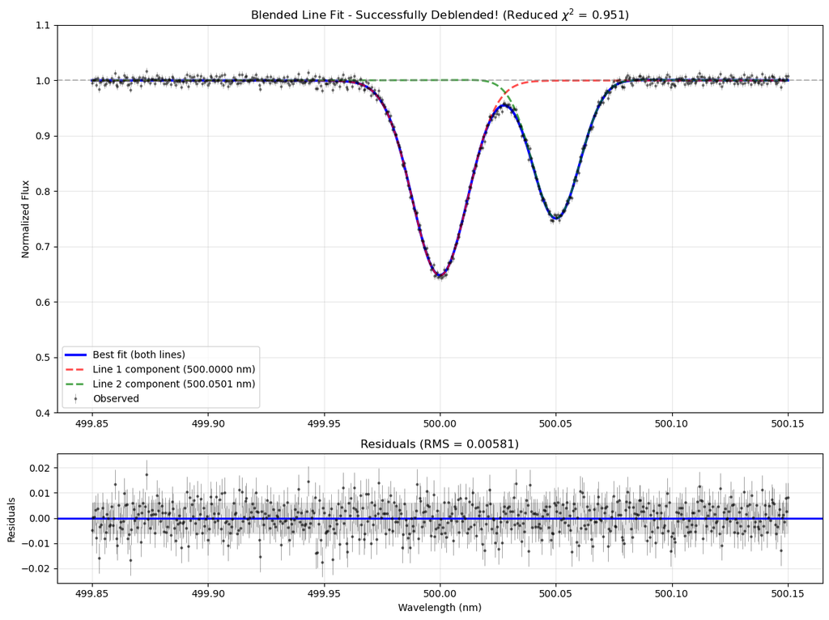

```python
# Visualize blend fitting results
fig, axes = plt.subplots(2, 1, figsize=(12, 9),
                         gridspec_kw={'height_ratios': [3, 1]})

# Top panel: data, fit, and components
axes[0].errorbar(wavelength_blend, flux_blend_noisy, yerr=noise_blend,
                fmt='ko', markersize=2, alpha=0.4, elinewidth=0.5, capsize=0,
                label='Observed')
axes[0].plot(wavelength_blend, flux_fit_blend, 'b-', linewidth=2.5,
            label='Best fit (both lines)')
axes[0].plot(wavelength_blend, flux_comp1_blend, 'r--', linewidth=2, alpha=0.7,
            label=f'Line 1 component ({fit_center1_blend:.4f} nm)')
axes[0].plot(wavelength_blend, flux_comp2_blend, 'g--', linewidth=2, alpha=0.7,
            label=f'Line 2 component ({fit_center2_blend:.4f} nm)')

axes[0].axhline(y=fit_cont_blend, color='gray', linestyle='--', alpha=0.5)
axes[0].set_ylabel('Normalized Flux')
axes[0].set_title(f'Blended Line Fit - Successfully Deblended! (Reduced $\\chi^2$ = {reduced_chi_squared_blend:.3f})')
axes[0].legend()
axes[0].grid(alpha=0.3)
axes[0].set_ylim([0.4, 1.1])

# Bottom panel: residuals
axes[1].errorbar(wavelength_blend, residuals_blend, yerr=noise_blend,
                fmt='ko', markersize=2, alpha=0.5, elinewidth=0.5, capsize=0)
axes[1].axhline(y=0, color='b', linestyle='-', linewidth=2)
axes[1].fill_between(wavelength_blend, -noise_blend, noise_blend,
                     alpha=0.2, color='gray')
axes[1].set_xlabel('Wavelength (nm)')
axes[1].set_ylabel('Residuals')
axes[1].set_title(f'Residuals (RMS = {np.std(residuals_blend):.5f})')
axes[1].grid(alpha=0.3)

plt.tight_layout()
plt.show()
```

The fit successfully deblends the lines! The observed complex profile (black points) is explained by two Voigt components (red and green dashed lines) that sum to produce the best-fit model (blue line). The residuals show only random noise—no systematic structure remains, confirming that our two-component Voigt model adequately describes the data.

The importance of blends in real spectroscopy cannot be overstated. Cool stars (spectral types K and M) have thousands of overlapping absorption lines from molecules like TiO, making most features blended. Heavy elements have complex atomic structure producing multiple close transitions. Even apparently "clean" lines often have weak blends lurking nearby. Professional spectral analysis carefully models all known blends, often fitting 10-20 lines simultaneously in complex regions.

The lesson: when you see an asymmetric or unusually broad line in a spectrum, consider whether it might be blended. Try fitting with multiple components before concluding it's a single feature. Blending is ubiquitous, and handling it properly is essential for accurate spectroscopy.

## Summary

This lecture introduced spectroscopic fitting—analyzing one-dimensional spectra to extract physical information about stars. You learned how spectroscopy complements photometry by trading sensitivity for detailed wavelength-dependent information, enabling measurements impossible with broadband imaging.

### Key Concepts

- **Trade-off:** Photometry enables highly sensitive measurements because it collects all light within a broad wavelength band, leading to high signal-to-noise data for faint objects. However, this comes at the cost of losing information about how brightness varies with wavelength (no spectral features). Spectroscopy, on the other hand, spreads the light out by wavelength. This gives you detailed information about individual spectral lines and features, but lowers the signal registered by each pixel, requiring careful analysis and typically longer observing times.
- **Spectral Resolution:** The resolving power of a spectrograph determines how closely spaced two wavelengths can be and still be distinguished as separate features, not blended. Higher resolution allows astronomers to precisely measure Doppler shifts (velocities), resolve detailed structures in absorption or emission lines, and study subtle line shapes related to physical phenomena. It is essential for accurate measurement of line positions, widths, and for disentangling blends of neighboring features.
- **Line Broadening:** The detailed shapes (profiles) of spectral lines contain important clues about the physical conditions within an astronomical object. Random thermal motions of atoms lead to Gaussian (bell-shaped) broadening, while quantum effects and pressure in dense regions produce Lorentzian (winged) profiles. Stellar rotation further broadens and distorts profiles, often producing flattened or asymmetric shapes. The observed profile is often a combination of these effects; the Voigt profile (a convolution of Gaussian and Lorentzian) is commonly used to model real lines in stellar spectra.
- **Fitting Spectral Lines:** Extracting quantitative information such as the center, width, amplitude, and shape of spectral lines requires fitting functions (such as Gaussians, Lorentzians, or Voigt profiles) to the data. This is typically done using non-linear least-squares algorithms—`scipy.optimize.curve_fit` is a standard tool—which not only finds best-fit parameters but also estimates their uncertainties. Good initial parameter guesses and the choice of an appropriate model become especially important when lines are blended or the spectrum is noisy.
- **Equivalent Width (EW):** The equivalent width quantifies the total "strength" of an absorption or emission line by representing it as the width of a rectangle with the same area as the line and the same continuum height. This provides a robust, model-independent measure that allows for direct comparison between different lines or with theoretical predictions. EW is invaluable in abundance studies because it is not affected by instrument resolution or modest changes in profile shape.
- **Continuum Normalization:** Precise scientific measurement requires that the spectrum’s continuum—the undisturbed baseline flux level—be correctly estimated and normalized to a constant value. Poor continuum placement can bias all subsequent line measurements (depth, width, EW) and lead to inaccurate physical interpretations. Careful normalization is especially vital for crowded or blended regions, and is an essential preparatory step before any quantitative line analysis.

### What You Can Now Do

After completing this material, you should be able to:

- Explain the key trade-off between sensitivity and information content in photometry vs. spectroscopy.
- Calculate spectral resolution $R$ and relate it to velocity measurements.
- Recognize and interpret the main broadening mechanisms in stellar spectra.
- Fit single and blended lines with Gaussian, Lorentzian, and Voigt profiles using `curve_fit`.
- Calculate equivalent widths numerically, and use them to compare elemental abundances.
- Normalize spectra and assess the quality of your fits using residuals and reduced $\chi^2$.

These techniques form the foundation of quantitative stellar spectroscopy used throughout astronomy to determine chemical compositions, measure rotation rates, probe atmospheric structure, and detect radial velocities. Every abundance measurement, every stellar parameter determination, and every exoplanet radial velocity detection ultimately relies on fitting spectral line profiles using methods like those in this lecture.

### Looking Ahead

You've now completed the model-fitting trilogy: time series fitting (Lecture 19: exoplanet transits), image fitting (Lecture 20: PSF photometry), and spectral fitting (Lecture 21: line profiles and abundances). These three lectures applied the same optimization principles from Lecture 18 to increasingly complex astronomical data. The curve-fitting skills—defining models, using `scipy.optimize.curve_fit`, assessing goodness-of-fit, propagating uncertainties—are universal tools for extracting physical information from observations.

In Lecture 22, we'll explore a completely different topic: the Model Context Protocol (MCP), which provides standardized ways for AI systems to interact with tools and data sources. You'll learn how to build MCP servers that connect language models to specialized astronomical workflows, creating intelligent assistants that can query databases, analyze data, and generate visualizations. This represents a paradigm shift: instead of writing explicit analysis scripts, you'll create tools that AI systems can use to solve problems autonomously—a powerful approach for complex, exploratory research tasks.